# Code for Replication in R and Stata

- Show All Code
- Hide All Code
- View Source

# Introduction

In this appendix we provide the code to replicate the tables and figures in the article. By pressing the $\triangleright$ code button you can see the R code that creates the relevant figure or table, with a description of the steps involved in computing the analyses.

# Table 1: Medicaid Expansion Adoption

The following code block produces **Table 1**, which shows the roll-out of Medicaid Expansion under the Affordable Care Act (ACA) across states.

**R**

```r
## Install packages from Github if needed
# load packages
library(tidyverse)
library(kableExtra)
library(modelsummary)
library(gt)
library(did)
library(ggthemes)
library(fixest)
library(latex2exp)
library(HonestDiD)

# omit NA from tables
options(knitr.kable.NA = '')

# set baseline output for modelsummary
options(modelsummary_factory_default = 'kableExtra')

# set ggplot theme
theme_set(
  theme_clean() +
    theme(plot.background = element_blank(),
          legend.background = element_rect(color = "white"),
          strip.background = element_rect(color = "black"))
)

# load cleaned data
mydata <- read_csv(here::here("data", "county_mortality_data.csv")) %>%
  # make state the abbreviation
  mutate(state = str_sub(county, nchar(county) - 1, nchar(county))) %>%
  # drop District of Columbia from the data
  filter(state != "DC") %>%
  # make a second adoption variable for the table
  mutate(adopt = case_when(
    # missing is non-expansion
    is.na(yaca) ~ "Non-Expansion",
    # fix a couple pre-2014 adoptions from Miller, Johnson and Wherry
    state %in% c("DE", "MA", "NY", "VT") ~ "Pre-2014",
    TRUE ~ as.character(yaca)
  ))

# get adoption year by state
adopts <- mydata %>%
  select(state, adopt) %>%
  distinct() %>%
  arrange(state)

# first get the share of states, share of counties, and share of adults in 2013 by adoption category
# first the states and share of states
states <- adopts %>%
  group_by(adopt) %>%
  summarize(states = paste0(state, collapse = ", "),
            state_share = length(state) / 50)

# next get the county share and the population share
counties_pop <- mydata %>%
  # just for year 2013
  filter(year == 2013) %>%
  # get county and population totals
  mutate(total_counties = n(),
         total_pop = sum(population_20_64, na.rm = TRUE)) %>%
  group_by(adopt) %>%
  # make into shares
  summarize(county_share = n() / mean(total_counties),
            pop_share = sum(population_20_64, na.rm = TRUE) / mean(total_pop))

# make a table and export
states %>%
  left_join(counties_pop, by = "adopt") %>%
  slice(9, 1:8) %>%
  # format the numbers to two digits
  mutate(across(state_share:pop_share, ~ scales::number(., accuracy = 0.01))) %>%
  # format the table
  kable(
    col.names = c("Expansion \n Year", "States", "Share of States", "Share of Counties",
                  "Share of Adults (2013)"),
    booktabs = T, caption = "Medicaid Expansion Under the Affordable Care Act",
    label = "adoptions",
    align = c("c"),
    escape = FALSE,
    linesep = ""
  ) %>%
  kable_styling(latex_options = c("scale_down", "HOLD_position")) %>%
  column_spec(2, width = "20em")
```

Medicaid Expansion Under the Affordable Care Act

| Expansion Year | \| States | \| Share of States | \| Share of Counties | \| Share of Adults (2013) |
| --- | --- | --- | --- | --- |
| Pre-2014 | DE, MA, NY, VT | 0.08 | 0.03 | 0.09 |
| 2014 | AR, AZ, CA, CO, CT, HI, IA, IL, KY, MD, MI, MN, ND, NH, NJ, NM, NV, OH, OR, RI, WA, WV | 0.44 | 0.36 | 0.45 |
| 2015 | AK, IN, PA | 0.06 | 0.06 | 0.06 |
| 2016 | LA, MT | 0.04 | 0.04 | 0.02 |
| 2019 | ME, VA | 0.04 | 0.05 | 0.03 |
| 2020 | ID, NE, UT | 0.06 | 0.04 | 0.02 |
| 2021 | MO, OK | 0.04 | 0.06 | 0.03 |
| 2023 | NC, SD | 0.04 | 0.05 | 0.03 |
| Non-Expansion | AL, FL, GA, KS, MS, SC, TN, TX, WI, WY | 0.20 | 0.31 | 0.26 |

**Stata**

```stata
clear
capture log close

******************************************************************************
* 1. Load original data
******************************************************************************
    cd "../../data"
  insheet using "county_mortality_data.csv", clear

    keep state county_code county year yaca population_20_64

    *Define treatment timing
    gen treat_year = real(yaca)
    replace treat_year = 0 if missing(treat_year)
    tostring treat_year, gen(treat_str)
    destring yaca, replace force

    destring population_20_64, replace force

    * Drop DC as in JEL Table 1
    drop if state == "District of Columbia"

****************************************************
* 2. Create adoption category                      *
****************************************************
    gen adopt = ""
    replace adopt = "Pre-2014" if inlist(state, "Delaware", "Massachusetts", "New York", "Vermont")
    replace adopt = string(yaca) if !missing(yaca) & adopt == ""
    replace adopt = "Non-Expansion" if missing(yaca)

****************************************************
* 3. Get number of states and state share          *
****************************************************
preserve
gen st_abr = substr(county, max(1, strlen(county)-1), 2)
keep st_abr adopt
duplicates drop
sort adopt st_abr

by adopt: gen strL state_list = st_abr
by adopt: replace state_list = state_list[_n-1] + ", " + st_abr if adopt[_n-1] == adopt[_n]

bysort adopt: gen state_count=_N

gen state_share = state_count / 50

gen len= strlen(state_list)
bysort adopt: egen max=max(len)
keep if len==max

keep adopt state_list state_share
tempfile state_summary
save `state_summary', replace
restore
****************************************************
* 4. Get county & adult pop share (year = 2013)    *
****************************************************
    preserve
    keep if year == 2013

    * Total county count and total 20–64 pop in 2013
    su population_20_64
    scalar total_pop = r(sum)

    su county_code
    scalar total_counties = r(N)

    collapse (count) county_count=county_code (sum) pop=population_20_64, by(adopt)

    gen county_share = county_count / total_counties
    gen pop_share = pop / total_pop

    tempfile county_summary
    save `county_summary'
    restore

****************************************************
* 5. Merge and order categories for display        *
****************************************************
    use `state_summary', clear
    merge 1:1 adopt using `county_summary', nogen

    * Order like JEL Table 1
    gen order = .
    replace order = 1 if adopt == "Pre-2014"
    replace order = 2 if adopt == "2014"
    replace order = 3 if adopt == "2015"
    replace order = 4 if adopt == "2016"
    replace order = 5 if adopt == "2019"
    replace order = 6 if adopt == "2020"
    replace order = 7 if adopt == "2021"
    replace order = 8 if adopt == "2023"
    replace order = 9 if adopt == "Non-Expansion"
    sort order

    * Round to match JEL formatting
    gen state_share_fmt = string(state_share, "%4.2f")
    gen county_share_fmt = string(county_share, "%4.2f")
    gen pop_share_fmt = string(pop_share, "%4.2f")

****************************************************
* 6. Export table                                 *
****************************************************

export excel adopt state_list state_share_fmt county_share_fmt pop_share_fmt ///
    using "../data/adoptions_table.xlsx", firstrow(variables) replace
restore
```

# $2\times2$ DiD setups

The following tables and figures show our analyses within the $2\times2$ section of the paper.

## Table 2: Simple $2\times2$ DiD

**Table 2** shows how we can calculate the simple $2\times2$ DiD comparing the change in the crude mortality rates between states that chose to expand Medicaid in 2014 and those that had not yet expanded by 2019.

**R**

```r
# set seed for reproducibility
set.seed(20240924)

# set filepath locations for tables and figures
file.loc.tab <- here::here("tables/")
file.loc.fig <- here::here("figures/")

# load cleaned data
mydata <- read_csv(here::here("data", "county_mortality_data.csv")) %>%
  # make state the abbreviation
  mutate(state = str_sub(county, nchar(county) - 1, nchar(county))) %>%
  # drop DC and pre-2014 adoption states
  filter(!(state %in% c("DC", "DE", "MA", "NY", "VT"))) %>%
  # drop states that adopt between 2014 and 2019
  filter(yaca == 2014 | is.na(yaca) | yaca > 2019)

# set the covariates that we're going to use.
covs <- c("perc_female","perc_white", "perc_hispanic", "unemp_rate", "poverty_rate", "median_income")

## Clean data and add in covariates
mydata <- mydata %>%
  # make variables
  mutate(perc_white = population_20_64_white / population_20_64 * 100,
         perc_hispanic = population_20_64_hispanic / population_20_64 * 100,
         perc_female = population_20_64_female/ population_20_64 * 100,
         unemp_rate = unemp_rate * 100,
         median_income = median_income / 1000) %>%
  # keep just subset of variables that we will use later
  select(state, county, county_code, year, population_20_64, yaca,
         starts_with("perc_"), crude_rate_20_64, all_of(covs))

# keep only counties with full observations for outcome and covariates in 2013 and 2014
mydata <- mydata %>%
  # allow the aca expansion variable to be missing
  drop_na(!yaca) %>%
  group_by(county_code) %>%
  # need full covariates for 2013 and 2014
  filter(length(which(year == 2013 | year == 2014)) == 2) %>%
  ungroup()

# finally, keep only counties with full mortality data for 2009 to 2019
mydata <- mydata %>%
  group_by(county_code) %>%
  drop_na(crude_rate_20_64) %>%
  filter(n() == 11)

# make a smaller dataset with only years 2013 and 2014
short_data <- mydata %>%
  # make a binary variable that identifies ACA expansion and post-years
  mutate(Treat = if_else(yaca == 2014 & !is.na(yaca), 1, 0),
         Post = if_else(year == 2014, 1, 0)) %>%
  # filter years for just 2013 and 2014
  filter(year %in% c(2013, 2014)) %>%
  # make a variable with population weight in 2013
  group_by(county_code) %>%
  mutate(set_wt = population_20_64[which(year == 2013)]) %>%
  ungroup()

# get group means for Table 2
# unweighted expansion pre-reform
T_pre <- short_data %>%
  filter(Treat == 1 & year == 2013) %>%
  summarize(mean = mean(crude_rate_20_64)) %>%
  pull(mean)

# unweighted non-expansion pre-form
C_pre <- short_data %>%
  filter(Treat == 0 & year == 2013) %>%
  summarize(mean = mean(crude_rate_20_64)) %>%
  pull(mean)

# unweighted expansion post-reform
T_Post <- short_data %>%
  filter(Treat == 1 & year == 2014) %>%
  summarize(mean = mean(crude_rate_20_64)) %>%
  pull(mean)

# unweighted non-expansion post-reform
C_Post <- short_data %>%
  filter(Treat == 0 & year == 2014) %>%
  summarize(mean = mean(crude_rate_20_64)) %>%
  pull(mean)

# get the same group means but this time weighted
T_pre_weight <- short_data %>%
  filter(Treat == 1 & year == 2013) %>%
  summarize(mean = weighted.mean(crude_rate_20_64, w = set_wt)) %>%
  pull(mean)

C_pre_weight <- short_data %>%
  filter(Treat == 0 & year == 2013) %>%
  summarize(mean = weighted.mean(crude_rate_20_64, w = set_wt)) %>%
  pull(mean)

T_Post_weight <- short_data %>%
  filter(Treat == 1 & year == 2014) %>%
  summarize(mean = weighted.mean(crude_rate_20_64, w = set_wt)) %>%
  pull(mean)

C_Post_weight <- short_data %>%
  filter(Treat == 0 & year == 2014) %>%
  summarize(mean = weighted.mean(crude_rate_20_64, w = set_wt)) %>%
  pull(mean)

# function to do a reasonable rounding
g_round <- function(x, k) {format(round(x, k), nsmall = k)}

# make table and export
tribble(
  ~"", ~"Expansion", ~ "No Expansion", ~"Gap/DiD", ~"Expansion", ~"No Expansion", ~"Gap/DiD",
  "2013", as.character(g_round(T_pre, 1)), as.character(g_round(C_pre, 1)), as.character(g_round(T_pre - C_pre, 1)),
  as.character(g_round(T_pre_weight, 1)), as.character(g_round(C_pre_weight, 1)), as.character(g_round(T_pre_weight - C_pre_weight, 1)),
  "2014", as.character(g_round(T_Post, 1)), as.character(g_round(C_Post, 1)), as.character(g_round(T_Post - C_Post, 1)),
  as.character(g_round(T_Post_weight, 1)), as.character(g_round(C_Post_weight, 1)), as.character(g_round(T_Post_weight - C_Post_weight, 1)),
  "Trend/DiD", as.character(g_round(T_Post - T_pre, 1)), as.character(g_round(C_Post-C_pre, 1)),
  as.character(g_round((T_Post - T_pre) - (C_Post-C_pre), 1)),
    as.character(g_round(T_Post_weight - T_pre_weight, 1)), as.character(g_round(C_Post_weight-C_pre_weight, 1)),
  as.character(g_round((T_Post_weight - T_pre_weight) - (C_Post_weight-C_pre_weight), 1))
) %>%
  # format table
  kable(align = 'c',
        booktabs = T,
        escape = F,
        caption = "Simple 2 X 2 DiD") %>%
  kable_styling() %>%
  row_spec(3, color = "BrickRed") %>%
  column_spec(c(1:3, 5:6), color = "black") %>%
  row_spec(3, italic = TRUE) %>%
  column_spec(c(4, 7), italic = TRUE) %>%
  add_header_above(c(" " = 1, "Unweighted Averages" = 3, "Weighted Averages" = 3))
```

Simple 2 X 2 DiD

|  | Unweighted Averages Expansion | Unweighted Averages No Expansion | Unweighted Averages Gap/DiD | Weighted Averages Expansion | Weighted Averages No Expansion | Weighted Averages Gap/DiD |
| --- | --- | --- | --- | --- | --- | --- |
| 2013 | 419.2 | 474.0 | -54.8 | 322.7 | 376.4 | -53.7 |
| 2014 | 428.5 | 483.1 | -54.7 | 326.5 | 382.7 | -56.2 |
| Trend/DiD | 9.3 | 9.1 | 0.1 | 3.7 | 6.3 | -2.6 |

**Stata**

```stata
********************************
* 1. Load and prepare data
********************************
    clear all
    set more off
    capture log close

    insheet using "county_mortality_data.csv", clear

********************************
* 2. Prepare timing groups
********************************
    *Drop early and mid adopters
    drop if inlist(state, "District of Columbia", "Delaware", "Massachusetts", "New York", "Vermont")

    *Define treatment timing
    gen treat_year = real(yaca)
    replace treat_year = 0 if missing(treat_year)
    tostring treat_year, gen(treat_str)
    destring yaca, replace force

********************************
* 3. Prepare covariates
********************************
    *destring covariates
    destring deaths population_20_64 crude_rate_20_64 population_total population_20_64_hispanic population_20_64_female population_20_64_white unemployed labor_force unemp_rate poverty_rate median_income, replace force
    ren population_total total_population

    *Drop counties with missing covariates
    gen perc_white    = population_20_64_white   / population_20_64 * 100
    gen perc_hispanic = population_20_64_hispanic/ population_20_64 * 100
    gen perc_female   = population_20_64_female  / population_20_64 * 100
    gen unemp_rate_pc = unemp_rate * 100
    gen median_income_k = median_income/1000
    drop if missing(crude_rate_20_64, population_20_64, ///
                    perc_white, perc_hispanic, perc_female, ///
                    unemp_rate_pc, poverty_rate, median_income_k)

********************************
* 4. Sample construction
********************************
    *Keep counties with full 11-year panel
    bys county_code (year): gen panel_n = _N
    bys county_code: keep if panel_n == 11
    drop panel_n
    replace treat_year=0 if treat_year>2019

********************************
* 5. Construct population weight
********************************
    bys county_code: egen set_wt = max(cond(year==2013, population_20_64, .))

********************************
* 6. Label variables
********************************
    label variable crude_rate_20_64 "Crude Mortality Rate"



save "did_jel_aca_replication_data", replace

***************************************************************
*1. Table 2: weighted and unweighted averages for the simple 2x2 DiD
***************************************************************
    *Read in data, keep 2013–2014 and 2014 expansion vs "non expansion" states
    use "did_jel_aca_replication_data", clear
    keep if inlist(year, 2013, 2014) & inlist(yaca,2014,2020,2021,2023,.)
    gen Treat = (yaca==2014)        // 1 = ACA in 2014
    gen Post = (year == 2014)       // 1 = post-expansion year

    *Means
    *unweighted
    sum crude_rate if Treat==1 & year==2014
    global u12014 = r(mean)
    sum crude_rate if Treat==1 & year==2013
    global u12013 = r(mean)
    sum crude_rate if Treat==0 & year==2014
    global u02014 = r(mean)
    sum crude_rate if Treat==0 & year==2013
    global u02013 = r(mean)

    *weighted
    sum crude_rate if Treat==1 & year==2014 [aw=set_wt]
    global w12014 = r(mean)
    sum crude_rate if Treat==1 & year==2013  [aw=set_wt]
    global w12013 = r(mean)
    sum crude_rate if Treat==0 & year==2014  [aw=set_wt]
    global w02014 = r(mean)
    sum crude_rate if Treat==0 & year==2013 [aw=set_wt]
    global w02013 = r(mean)



    *Gaps, trends, DiDs
    * Unweighted
    global Gap13_u = ($u12013 - $u02013)
    global Gap14_u = ($u12014 - $u02014)
    global DiD_u   = ( ($u12014 - $u12013) - ($u02014 - $u02013) )
    global Trend_T_u = ($u12014 - $u12013)
    global Trend_C_u = ($u02014 - $u02013)

    * Weighted
    global Gap13_w = ($w12013 - $w02013)
    global Gap14_w = ($w12014 - $w02014)
    global DiD_w   = ( $w12014 - $w12013 ) - ( $w02014 - $w02013 )
    global Trend_T_w = ($w12014 - $w12013)
    global Trend_C_w = ($w02014 - $w02013)



    *Rounding for the table
    foreach nm in u12013 u02013 u12014 u02014 ///
                 w12013 w02013 w12014 w02014 ///
                 Gap13_u Gap14_u DiD_u Trend_T_u Trend_C_u ///
                 Gap13_w Gap14_w DiD_w Trend_T_w Trend_C_w {
        local `nm' : display %6.1f ${`nm'}
        display("`nm'")
    }

    display("`u12013'")
    display "$u12013"
    * Brick-red DiD cells
    local DiD_u_cell "\em{\em{\textcolor{BrickRed}{`DiD_u'}}}"
    local DiD_w_cell "\em{\em{\textcolor{BrickRed}{`DiD_w'}}}"




/*--------------------------------------------------------------------
  8. Export Excel Table for Rendering
--------------------------------------------------------------------*/
clear
set obs 3

// row labels
gen str10 row = ""
replace row = "2013"      in 1
replace row = "2014"      in 2
replace row = "Trend/DiD" in 3

// columns (numeric); convert locals like `u12013' to numbers with real()
gen double Expansion_unw   = .
gen double NoExpansion_unw = .
gen double Gap_DiD_unw     = .
gen double Expansion_wt    = .
gen double NoExpansion_wt  = .
gen double Gap_DiD_wt      = .

replace Expansion_unw   = real("`u12013'")    in 1
replace Expansion_unw   = real("`u12014'")    in 2
replace Expansion_unw   = real("`Trend_T_u'") in 3

replace NoExpansion_unw = real("`u02013'")    in 1
replace NoExpansion_unw = real("`u02014'")    in 2
replace NoExpansion_unw = real("`Trend_C_u'") in 3

replace Gap_DiD_unw     = real("`Gap13_u'")   in 1
replace Gap_DiD_unw     = real("`Gap14_u'")   in 2
replace Gap_DiD_unw     = real("`DiD_u'")     in 3

replace Expansion_wt    = real("`w12013'")    in 1
replace Expansion_wt    = real("`w12014'")    in 2
replace Expansion_wt    = real("`Trend_T_w'") in 3

replace NoExpansion_wt  = real("`w02013'")    in 1
replace NoExpansion_wt  = real("`w02014'")    in 2
replace NoExpansion_wt  = real("`Trend_C_w'") in 3

replace Gap_DiD_wt      = real("`Gap13_w'")   in 1
replace Gap_DiD_wt      = real("`Gap14_w'")   in 2
replace Gap_DiD_wt      = real("`DiD_w'")     in 3

format Expansion_unw NoExpansion_unw Gap_DiD_unw ///
       Expansion_wt  NoExpansion_wt  Gap_DiD_wt %9.1f

export excel using "../data/two_by_two_table.xlsx", firstrow(variables) replace
```

## Table 3: Regression DiD

**Table 3** shows how we can recover the same $2\times2$ estimate using one of three regression specifications:

1) Regressing the crude mortality rate on indicators for treatment (Medicaid expansion states), post-treatment periods (2014), and the interaction of the two.

2) Regressing the crude mortality rate on the interaction of indicators for Medicaid expansion and post-expansion periods, as well as county and year fixed effects.

3) Regressing the difference between 2014 and 2013 county-level crude mortality rates on an indicator for whether the county is in a state that expanded Medicaid.

**R**

```r
# show that you can get the same estimates with regression
# make a different short data with long differences in mortality by county and treatment indicators
short_data2 <- short_data %>%
  group_by(county_code) %>%
  summarize(state = state[1],
            set_wt = mean(set_wt),
            # long difference between 2014 and 2013 rates
            diff = crude_rate_20_64[which(year == 2014)] - crude_rate_20_64[which(year == 2013)],
            Treat = mean(Treat),
            Post = 1)

# estimate three models without weights. These are Treat*Post with no fixed effects,
# fixed effects + Treat:Post, and then the long difference model with no fixed effects.
mod1 <- feols(crude_rate_20_64 ~ Treat*Post, data = short_data, cluster = ~county_code)
mod2 <- feols(crude_rate_20_64 ~ Treat:Post | county_code + year, data = short_data, cluster = ~county_code)
mod3 <- feols(diff ~ Treat:Post, data = short_data2, cluster = ~county_code)

# estimate the same three three models with weights
mod4 <- feols(crude_rate_20_64 ~ Treat*Post, data = short_data, weights = ~set_wt, cluster = ~county_code)
mod5 <- feols(crude_rate_20_64 ~ Treat:Post | county_code + year, data = short_data,
              weights = ~set_wt, cluster = ~county_code)
mod6 <- feols(diff ~ Treat:Post, data = short_data2, weights = ~set_wt, cluster = ~county_code)


# this dictionary maps names to labels for the table
dict <- c("(Intercept)" = "Constant",
          "Treat" = "Medicaid Expansion",
          "Post" = "Post",
          "Treat:Post" = "Medicaid Expansion X Post")

# rows to add to table
rows = tribble(
  ~x1, ~x2, ~x3, ~x4, ~x5, ~x6, ~x7,
  "County fixed effects", "No", "Yes", "No", "No", "Yes", "No",
  "Year fixed effects", "No", "Yes", "No", "No", "Yes", "No"
)

# export table 3
modelsummary(list("(1)" = mod1, "(2)" = mod2, "(3)" = mod3,
                  "(4)" = mod4, "(5)" = mod5, "(6)" = mod6),
             coef_map = dict, escape = FALSE, gof_map = NA,
             fmt = 1, stars = FALSE,
             estimate = "{estimate}", add_rows = rows,
             title = "Regression 2 X 2 DiD") %>%
  add_header_above(c(" " = 1, "Crude Morality Rate" = 2, "\\(\\Delta\\)" = 1,
                     "Crude Mortality Rate" = 2, "\\(\\Delta\\)" = 1), escape = FALSE)
```

Regression 2 X 2 DiD

|  | Crude Morality Rate (1) | Crude Morality Rate (2) | \(\Delta\) (3) | Crude Mortality Rate (4) | Crude Mortality Rate (5) | \(\Delta\) (6) |
| --- | --- | --- | --- | --- | --- | --- |
| Constant | 474.0 |  | 9.1 | 376.4 |  | 6.3 |
|  | (4.3) |  | (2.6) | (7.6) |  | (1.1) |
| Medicaid Expansion | −54.8 |  |  | −53.7 |  |  |
|  | (6.3) |  |  | (11.5) |  |  |
| Post | 9.1 |  |  | 6.3 |  |  |
|  | (2.6) |  |  | (1.1) |  |  |
| Medicaid Expansion X Post | 0.1 | 0.1 | 0.1 | −2.6 | −2.6 | −2.6 |
|  | (3.7) | (3.7) | (3.7) | (1.5) | (1.5) | (1.5) |
| County fixed effects | No | Yes | No | No | Yes | No |
| Year fixed effects | No | Yes | No | No | Yes | No |

**Stata**

```stata
***************************************************************
*2. Table 3: regression 2x2 DiD with balanced panel, no controls
***************************************************************
    *Read in data, keep 2013–2014 and 2014 expansion vs "non expansion" states
    use "did_jel_aca_replication_data", clear
    keep if inlist(year, 2013, 2014) & inlist(yaca,2014,2020,2021,2023,.)
    gen Treat = (yaca==2014)        // 1 = ACA in 2014
    gen Post = (year == 2014)       // 1 = post-expansion year

    *Panel declaration (once)
    xtset county_code year

    *UNWEIGHTED regressions
    eststo clear
    * (1) Treat × Post, no FE
    reg crude_rate_20_64 c.Treat##c.Post, vce(cluster county_code)
    eststo m1
    estadd local countyfe "No"
    estadd local yearfe   "No"

    * (2) Treat × Post with county & year FE  (xtreg, fe → no constant)
    xtreg crude_rate_20_64 c.Treat#c.Post i.year, fe vce(cluster county_code)
    eststo m2
    estadd local countyfe "Yes"
    estadd local yearfe   "Yes"

* (3) Long-difference, unweighted
preserve
    keep county_code year crude_rate_20_64 Treat
    reshape wide crude_rate_20_64, i(county_code) j(year)
    gen diff = crude_rate_20_642014 - crude_rate_20_642013
    label variable diff "\$\\Delta\$"
    reg diff Treat, vce(cluster county_code)

    // rename Treat -> c.Treat#c.Post and re-post BEFORE eststo
    tempname b V
    matrix `b' = e(b)
    matrix `V' = e(V)
    local N  = e(N)
    local df = e(df_r)
    tempvar touse
    gen byte `touse' = e(sample)
    local cn : colnames `b'
    local newcn
    foreach nm of local cn {
        if ("`nm'" == "Treat") local newcn `newcn' c.Treat#c.Post
        else                   local newcn `newcn' `nm'
    }
    matrix colnames `b' = `newcn'
    matrix colnames `V' = `newcn'
    matrix rownames `V' = `newcn'
    ereturn post `b' `V', depname(diff) esample(`touse') obs(`N') dof(`df')

    eststo m3
    estadd local countyfe "No"
    estadd local yearfe   "No"
restore

    *WEIGHTED regressions
    * (4) Weighted, no FE
    reg crude_rate_20_64 c.Treat##c.Post [aw=set_wt], vce(cluster county_code)
    eststo m4
    estadd local countyfe "No"
    estadd local yearfe   "No"

    * (5) Weighted, county & year FE  (areg keeps _cons; we'll hide it)
    xtreg crude_rate_20_64 c.Treat#c.Post i.year [aw=set_wt], ///
        fe vce(cluster county_code)
    eststo m5
    estadd local countyfe "Yes"
    estadd local yearfe   "Yes"


* (6) Weighted long-difference
preserve
    keep county_code year crude_rate_20_64 Treat set_wt
    reshape wide crude_rate_20_64, i(county_code) j(year)
    gen diff = crude_rate_20_642014 - crude_rate_20_642013
    reg diff Treat [aw=set_wt], vce(cluster county_code)

    // rename Treat -> c.Treat#c.Post and re-post BEFORE eststo
    tempname b V
    matrix `b' = e(b)
    matrix `V' = e(V)
    local N  = e(N)
    local df = e(df_r)
    tempvar touse
    gen byte `touse' = e(sample)
    local cn : colnames `b'
    local newcn
    foreach nm of local cn {
        if ("`nm'" == "Treat") local newcn `newcn' c.Treat#c.Post
        else                   local newcn `newcn' `nm'
    }
    matrix colnames `b' = `newcn'
    matrix colnames `V' = `newcn'
    matrix rownames `V' = `newcn'
    ereturn post `b' `V', depname(diff) esample(`touse') obs(`N') dof(`df')

    eststo m6
    estadd local countyfe "No"
    estadd local yearfe   "No"
restore


    *Build the LaTeX table
    local labels ///
        _cons            "Constant" ///
        Treat            "Medicaid Expansion" ///
        Post             "Post" ///
        c.Treat#c.Post   "Medicaid Expansion × Post"

    * Add Treat as the interaction label in long-diff specs (m3 and m6)
    estimates restore m3
    estadd local intlabel "Medicaid Expansion × Post"
    estimates restore m6
    estadd local intlabel "Medicaid Expansion × Post"

esttab m1 m2 m3 m4 m5 m6 using "../data/regdid_2x2.csv", replace keep(_cons Treat Post c.Treat#c.Post)   order(_cons Treat Post c.Treat#c.Post)  varlabels(_cons "Constant" Treat "Medicaid Expansion" Post  "Post"  c.Treat#c.Post "Medicaid Expansion × Post") cells(b(fmt(%9.1f) ) se(fmt(%9.1f) )) collabels(none) stats( countyfe yearfe, fmt(%9.0g %9s %9s) labels("County fixed effects" "Year fixed effects")) nomtitles nonotes noobs numbers  plain csv
```

## Table 4: Covariate Balance

In **Table 4** we show how to check for covariate balance across the covariates, using both 2013 levels and the changes between 2014 and 2013. We include a measure of the normalized difference as well as the (unweighted and weighted) sample means.

**R**

```r
# Now, make the covariate balance table (Table 4).
# unweighted - pre
unweighted <- short_data %>%
  filter(year == 2013) %>%
  select(Treat, all_of(covs)) %>%
  group_by(Treat) %>%
  # get mean and standard deviation
  summarize_all(list(mean, var)) %>%
  # pivot the data longer
  pivot_longer(cols = !Treat,
               names_to = "variable",
               values_to = "value") %>%
  # now make separate columns for treated and untreated
  pivot_wider(names_from = "Treat",
              values_from = "value",
              names_prefix = "group") %>%
  # separate mean and standard deviations
  extract(variable, into = c("variable", "fx"), "(.*)_(.*)") %>%
  pivot_wider(id_cols = variable,
              names_from = fx,
              values_from = c(group0, group1)) %>%
  # make normalized difference
  mutate(norm_diff = (group1_fn1 - group0_fn1)/sqrt((group1_fn2 + group0_fn2)/2)) %>%
  select(variable, group0_fn1, group1_fn1, norm_diff)

# make a weighted variance function
wtd.var <- function (x, weights = NULL, normwt = FALSE, na.rm = TRUE,
                     method = c("unbiased", "ML"))
{
  method <- match.arg(method)
  if (!length(weights)) {
    if (na.rm)
      x <- x[!is.na(x)]
    return(var(x))
  }
  if (na.rm) {
    s <- !is.na(x + weights)
    x <- x[s]
    weights <- weights[s]
  }
  if (normwt)
    weights <- weights * length(x)/sum(weights)
  if (normwt || method == "ML")
    return(as.numeric(stats::cov.wt(cbind(x), weights, method = method)$cov))
  sw <- sum(weights)
  if (sw <= 1)
    warning("only one effective observation; variance estimate undefined")
  xbar <- sum(weights * x)/sw
  sum(weights * ((x - xbar)^2))/(sw - 1)
}

# weighted  - pre
weighted <- short_data %>%
  filter(year == 2013) %>%
  select(Treat, all_of(covs), set_wt) %>%
  group_by(Treat) %>%
  # get mean and standard deviation
  summarize(across(all_of(covs),
                   list(
                     ~weighted.mean(x = ., w = set_wt),
                     ~wtd.var(x = ., weights = set_wt, normwt = TRUE)))) %>%
  # pivot the data longer
  pivot_longer(cols = !Treat,
               names_to = "variable",
               values_to = "value") %>%
  # now make separate columns for treated and untreated
  pivot_wider(names_from = "Treat",
              values_from = "value",
              names_prefix = "group") %>%
  # separate mean and standard deviations
  extract(variable, into = c("variable", "fx"), "(.*)_(.*)") %>%
  pivot_wider(id_cols = variable,
              names_from = fx,
              values_from = c(group0, group1)) %>%
  # make normalized difference
  mutate(norm_diff = (group1_1 - group0_1)/sqrt((group1_2 + group0_2)/2)) %>%
  select(variable, group0_1, group1_1, norm_diff)

# make the top panel (weighted and unweighted Pre)
top_panel <- bind_cols(unweighted, weighted %>% select(-variable))

# make the bottom panel, which is the same thing but with the difference in X between 2014 and 2013.
# unweighted
unweighted <- short_data %>%
  select(county_code, year, Treat, all_of(covs)) %>%
  arrange(county_code, year) %>%
  group_by(county_code, Treat) %>%
  summarize(
    across(all_of(covs), function(x) x[2] - x[1])
  ) %>%
  ungroup() %>%
  select(-county_code) %>%
  group_by(Treat) %>%
  # get mean and standard deviation
  summarize_all(list(mean, var)) %>%
  # pivot the data longer
  pivot_longer(cols = !Treat,
               names_to = "variable",
               values_to = "value") %>%
  # now make separate columns for treated and untreated
  pivot_wider(names_from = "Treat",
              values_from = "value",
              names_prefix = "group") %>%
  # separate mean and standard deviations
  extract(variable, into = c("variable", "fx"), "(.*)_(.*)") %>%
  pivot_wider(id_cols = variable,
              names_from = fx,
              values_from = c(group0, group1)) %>%
  # make normalized difference
  mutate(norm_diff = (group1_fn1 - group0_fn1)/sqrt((group1_fn2 + group0_fn2)/2)) %>%
  select(variable, group0_fn1, group1_fn1, norm_diff)

# weighted
weighted <- short_data %>%
  select(county_code, year, Treat, all_of(covs)) %>%
  arrange(county_code, year) %>%
  group_by(county_code, Treat) %>%
  summarize(
    across(all_of(covs), function(x) x[2] - x[1])
  ) %>%
  ungroup() %>%
  left_join(short_data %>% filter(year == 2013) %>% select(county_code, set_wt),
            join_by(county_code)) %>%
  select(-county_code) %>%
  group_by(Treat) %>%
  # get mean and standard deviation
  summarize(across(all_of(covs),
                   list(
                     ~weighted.mean(x = ., w = set_wt),
                     ~wtd.var(x = ., weights = set_wt, normwt = TRUE)))) %>%
  # pivot the data longer
  pivot_longer(cols = !Treat,
               names_to = "variable",
               values_to = "value") %>%
  # now make separate columns for treated and untreated
  pivot_wider(names_from = "Treat",
              values_from = "value",
              names_prefix = "group") %>%
  # separate mean and standard deviations
  extract(variable, into = c("variable", "fx"), "(.*)_(.*)") %>%
  pivot_wider(id_cols = variable,
              names_from = fx,
              values_from = c(group0, group1)) %>%
  # make normalized difference
  mutate(norm_diff = (group1_1 - group0_1)/sqrt((group1_2 + group0_2)/2)) %>%
  select(variable, group0_1, group1_1, norm_diff)

# make the bottom panel
bottom_panel <- bind_cols(unweighted, weighted %>% select(-variable))

# bind the two panels
table <- bind_rows(top_panel, bottom_panel) %>%
  # reformat all columns to two digits
  mutate(across(-variable, \(x) scales::comma(x, accuracy = 0.01)))

# format Table 4 and export
table %>%
  # change column names
  mutate(variable =
           case_match(variable,
                      "perc_female" ~ "% Female",
                      "perc_white" ~ "% White",
                      "perc_hispanic" ~ "% Hispanic",
                      "unemp_rate" ~ "Unemployment Rate",
                      "poverty_rate" ~ "Poverty Rate",
                      "median_income" ~ "Median Income")) %>%
  # format latex table
  kable(col.names = c("Variable", "Non-Adopt", "Adopt", "Norm. Diff.", "Non-Adopt", "Adopt", "Norm. Diff."),
        align = 'lcccccc',
        escape = T,
        booktabs = T,
        label = "cov_balance",
        caption = "Covariate Balance Statistics",
        linesep = "") %>%
  kable_styling(latex_options = c("scale_down", "hold_position")) %>%
  pack_rows("2013 Covariate Levels", 1, 6) %>%
  pack_rows("2014 - 2013 Covariate Differences", 7, 12) %>%
  add_header_above(c(" " = 1, "Unweighted" = 3, "Weighted" = 3))
```

Covariate Balance Statistics

| Variable | Unweighted Non-Adopt | Unweighted Adopt | Unweighted Norm. Diff. | Weighted Non-Adopt | Weighted Adopt | Weighted Norm. Diff. |
| --- | --- | --- | --- | --- | --- | --- |
| **2013 Covariate Levels** |  |  |  |  |  |  |
| % Female | 49.43 | 49.33 | -0.03 | 50.48 | 50.07 | -0.24 |
| % White | 81.64 | 90.48 | 0.59 | 77.91 | 79.54 | 0.11 |
| % Hispanic | 9.64 | 8.23 | -0.10 | 17.01 | 18.86 | 0.11 |
| Unemployment Rate | 7.61 | 8.01 | 0.16 | 7.00 | 8.01 | 0.50 |
| Poverty Rate | 19.28 | 16.53 | -0.42 | 17.24 | 15.29 | -0.37 |
| Median Income | 43.04 | 47.97 | 0.43 | 49.31 | 57.86 | 0.68 |
| **2014 - 2013 Covariate Differences** |  |  |  |  |  |  |
| % Female | -0.02 | -0.02 | 0.00 | 0.02 | 0.01 | -0.09 |
| % White | -0.21 | -0.21 | 0.01 | -0.32 | -0.33 | -0.04 |
| % Hispanic | 0.20 | 0.21 | 0.04 | 0.25 | 0.33 | 0.29 |
| Unemployment Rate | -1.16 | -1.30 | -0.21 | -1.08 | -1.36 | -0.55 |
| Poverty Rate | -0.55 | -0.28 | 0.14 | -0.41 | -0.35 | 0.05 |
| Median Income | 0.98 | 1.11 | 0.06 | 1.10 | 1.74 | 0.32 |

**Stata**

```stata
***************************************************************
*3. Table 4: Covariate-balance table
*            NB:the table construction is a lot of lines here...
***************************************************************
    *Read in data, keep 2013–2014 and 2014 expansion vs "non expansion" states
    use "did_jel_aca_replication_data", clear
    keep if inlist(year, 2013, 2014) & inlist(yaca,2014,2020,2021,2023,.)
    gen Treat = (yaca==2014)        // 1 = ACA in 2014
    gen Post = (year == 2014)       // 1 = post-expansion year

    *local with covariate names
    local covs perc_female perc_white perc_hispanic ///
               unemp_rate_pc poverty_rate median_income_k

    *2013 levels — unweighted means, SDs, and normalized diff
    preserve
        keep if year == 2013

        *---- means and SDs in a single collapse -----------------------
        collapse (mean)  m_perc_female              = perc_female       ///
                         m_perc_white               = perc_white        ///
                         m_perc_hispanic            = perc_hispanic     ///
                         m_unemp_rate_pc            = unemp_rate_pc     ///
                         m_poverty_rate             = poverty_rate      ///
                         m_median_income_k          = median_income_k   ///
                 (sd)    sd_perc_female             = perc_female       ///
                         sd_perc_white              = perc_white        ///
                         sd_perc_hispanic           = perc_hispanic     ///
                         sd_unemp_rate_pc           = unemp_rate_pc     ///
                         sd_poverty_rate            = poverty_rate      ///
                         sd_median_income_k         = median_income_k,  ///
                 by(Treat)

        generate byte id = 1          // same value for both rows (Treat 0/1)

        *---- reshape into one wide row -------------------------------------
        reshape wide m* sd_*, i(id) j(Treat)
        drop id                       // no longer needed

        *---- normalized differences ----------------------------------
        foreach x in `covs'{
            gen nd_`x' = (m_`x'1 - m_`x'0) / ///
                         sqrt( (sd_`x'1^2 + sd_`x'0^2) / 2 )
        }

            keep m* nd_*                    // single-row dataset
            tempfile unwt_pre
            save `unwt_pre'
            list
    restore



    *2013 levels — weighted means, SDs, and normalized diff
    preserve
        keep if year == 2013

        *---- means and SDs in a single collapse -----------------------
        collapse (mean)  wm_perc_female             = perc_female       ///
                         wm_perc_white              = perc_white        ///
                         wm_perc_hispanic           = perc_hispanic     ///
                         wm_unemp_rate_pc           = unemp_rate_pc     ///
                         wm_poverty_rate            = poverty_rate      ///
                         wm_median_income_k         = median_income_k   ///
                 (sd)    sd_perc_female             = perc_female       ///
                         sd_perc_white              = perc_white        ///
                         sd_perc_hispanic           = perc_hispanic     ///
                         sd_unemp_rate_pc           = unemp_rate_pc     ///
                         sd_poverty_rate            = poverty_rate      ///
                         sd_median_income_k         = median_income_k   ///
                         [aw = set_wt], ///
                 by(Treat)

        generate byte id = 1          // same value for both rows (Treat 0/1)

        *---- reshape into one wide row -------------------------------------
        reshape wide wm* sd_*, i(id) j(Treat)
        drop id                       // no longer needed

        *---- normalized differences ----------------------------------
        foreach x in `covs'{
            gen wnd_`x' = (wm_`x'1 - wm_`x'0) / ///
                         sqrt( (sd_`x'1^2 + sd_`x'0^2) / 2 )
        }

            keep wm* wnd_*                    // single-row dataset
            tempfile wt_pre
            save `wt_pre'
            list
    restore


    * Differences - unweighted means, SDs, and normalized diff
    preserve
        *create differences
        for var `covs': egen bX = total(X*(year==2013)), by(county_code)
        for var `covs': gen d_X = X-bX

      keep if year == 2014

        *---- means and SDs in a single collapse -----------------------
        collapse (mean)  m_d_perc_female            = d_perc_female         ///
                         m_d_perc_white             = d_perc_white          ///
                         m_d_perc_hispanic          = d_perc_hispanic       ///
                         m_d_unemp_rate_pc          = d_unemp_rate_pc       ///
                         m_d_poverty_rate           = d_poverty_rate        ///
                         m_d_median_income_k        = d_median_income_k     ///
                 (sd)    sd_perc_female             = d_perc_female         ///
                         sd_perc_white              = d_perc_white          ///
                         sd_perc_hispanic           = d_perc_hispanic       ///
                         sd_unemp_rate_pc           = d_unemp_rate_pc       ///
                         sd_poverty_rate            = d_poverty_rate        ///
                         sd_median_income_k         = d_median_income_k,    ///
                 by(Treat)

        generate byte id = 1          // same value for both rows (Treat 0/1)

        *---- reshape into one wide row -------------------------------------
        reshape wide m* sd_*, i(id) j(Treat)
        drop id                       // no longer needed

        *---- normalized differences ----------------------------------
        foreach x in `covs'{
            gen nd_d_`x' = (m_d_`x'1 - m_d_`x'0) / ///
                         sqrt( (sd_`x'1^2 + sd_`x'0^2) / 2 )
        }

        keep m_d* nd_d*                    // single-row dataset
        tempfile unwt_diff
        save `unwt_diff'
        list
    restore

    * Differences - weighted means, SDs, and normalized diff
    preserve
        *create differences
        for var `covs': egen bX = total(X*(year==2013)), by(county_code)
        for var `covs': gen d_X = X-bX
    keep if year == 2014

        *---- means and SDs in a single collapse -----------------------
        collapse (mean)  wm_d_perc_female           = d_perc_female         ///
                         wm_d_perc_white            = d_perc_white          ///
                         wm_d_perc_hispanic         = d_perc_hispanic       ///
                         wm_d_unemp_rate_pc         = d_unemp_rate_pc       ///
                         wm_d_poverty_rate          = d_poverty_rate        ///
                         wm_d_median_income_k       = d_median_income_k     ///
                 (sd)    sd_perc_female             = d_perc_female         ///
                         sd_perc_white              = d_perc_white          ///
                         sd_perc_hispanic           = d_perc_hispanic       ///
                         sd_unemp_rate_pc           = d_unemp_rate_pc       ///
                         sd_poverty_rate            = d_poverty_rate        ///
                         sd_median_income_k         = d_median_income_k     ///
                         [aw = set_wt], ///
                 by(Treat)

        generate byte id = 1          // same value for both rows (Treat 0/1)

        *---- reshape into one wide row -------------------------------------
        reshape wide wm* sd_*, i(id) j(Treat)
        drop id                       // no longer needed

        *---- normalized differences ----------------------------------
        foreach x in `covs'{
            gen wnd_d_`x' = (wm_d_`x'1 - wm_d_`x'0) / ///
                         sqrt( (sd_`x'1^2 + sd_`x'0^2) / 2 )
        }

        keep wm* wnd_*                    // single-row dataset
        tempfile wt_diff
        save `wt_diff'
        list
    restore

    **table creation
    *Assemble the four blocks into one matrix
    use `unwt_pre',     clear
    merge 1:1 _n using `wt_pre',   nogen   // adds mw*  sw*  wnd_*
    merge 1:1 _n using `unwt_diff', nogen   // adds md*  nd_d*
    merge 1:1 _n using `wt_diff',  nogen   // adds mwd* swd* wnd_d_*

    de,f


    * ---- row labels ----------------------------------------------------
    local rowlbl  "% Female" "% White" "% Hispanic" ///
                  "Unemployment Rate" "Poverty Rate" "Median Income"
    local outrows
    local i = 1
    foreach v in `covs' {
        local outrows `"`outrows' `"`:word `i' of `rowlbl''"'"'
        local ++i
    }

    /* ---- build the 12 × 6 matrix ----------------------------------- */
    matrix T = J(12,6,.)
    local r 0
    foreach v of local covs {
        local ++r
        * rows 1–6 : 2013 levels
        matrix T[`r',1] = m_`v'0[1]         // un-wtd mean, Non-adopt
        matrix T[`r',2] = m_`v'1[1]         // un-wtd mean, Adopt
        matrix T[`r',3] = nd_`v'[1]         // un-wtd norm-diff
        matrix T[`r',4] = wm_`v'0[1]        // wtd mean,  Non-adopt
        matrix T[`r',5] = wm_`v'1[1]        // wtd mean,  Adopt
        matrix T[`r',6] = wnd_`v'[1]        // wtd norm-diff
    }

    foreach v of local covs {
        local ++r
        * rows 7–12 : 2014–2013 long-differences
        matrix T[`r',1] = m_d_`v'0[1]        // un-wtd ∆, Non-adopt
        matrix T[`r',2] = m_d_`v'1[1]        // un-wtd ∆, Adopt
        matrix T[`r',3] = nd_d_`v'[1]        // un-wtd norm-diff
        matrix T[`r',4] = wm_d_`v'0[1]       // **underscore added**
        matrix T[`r',5] = wm_d_`v'1[1]       // **underscore added**
        matrix T[`r',6] = wnd_d_`v'[1]       // wtd norm-diff
    }

    matrix rownames T = `outrows' `outrows'
    matrix colnames T = "Non-Adopt" "Adopt" "Norm. Diff." ///
                        "Non-Adopt" "Adopt" "Norm. Diff."



*--------------------------------------------------------------------
* 5.  Export to CSV instead of LaTeX
*--------------------------------------------------------------------

* Convert matrix T to a dataset
clear
svmat T

* Reorder so variable names come first

* Rename columns to something clear
rename T1 NonAdopt_unwt
rename T2 Adopt_unwt
rename T3 NormDiff_unwt
rename T4 NonAdopt_wt
rename T5 Adopt_wt
rename T6 NormDiff_wt

* After svmat/renames
foreach v of varlist NonAdopt_unwt Adopt_unwt NormDiff_unwt ///
                     NonAdopt_wt  Adopt_wt  NormDiff_wt {
    replace `v' = round(`v', .01)
      tostring `v', replace format(%9.2f) force
                     }


* Save as CSV
export delimited using "../data/cov_balance.csv", replace
```

## Table 5: Regression 2 $\times$ 2 DiD with Covariates

In **Table 5** we show how the 2 $\times$ 2 DiD estimates change with the inclusion of covariates using linear regression. You can do this in two ways - either controlling for the 2013 levels of the covariates, or the change in the covariates between 2014 and 2013. Even in this simple setting the results differ considerably.

**R**

```r
# make a table that includes the model 1) without covariates, 2) long regression with
# 2013 covariates values, 3) long regression with *difference* in covariate values.
reg_data_2013 <- short_data %>%
  # make long diff in y
  group_by(county_code) %>%
  summarize(long_y = crude_rate_20_64[which(year == 2014)] - crude_rate_20_64[which(year == 2013)]) %>%
  # merge in 2013 covariates
  left_join(short_data %>% filter(year == 2013) %>% select(county_code, state, Treat, set_wt, all_of(covs)),
            by = "county_code")

# this dataset has the change in X between 2014 and 2013 as controls
reg_data_change <- short_data %>%
  # make long diff in y
  group_by(county_code) %>%
  summarize(long_y = crude_rate_20_64[which(year == 2014)] - crude_rate_20_64[which(year == 2013)]) %>%
  # merge in change in covariate values
  left_join(short_data %>%
              group_by(county_code) %>%
              mutate(set_wt = set_wt[which(year == 2013)]) %>%
              group_by(county_code, state, Treat, set_wt) %>%
              summarize(
                across(all_of(covs), function(x) x[which(year == 2014)] - x[which(year == 2013)])
              ), by = "county_code")

# run the six models
# first unweighted - long diff no covs, 2013 covs, then change in covs
mod1 <- feols(long_y ~ Treat, data = reg_data_2013, cluster = ~county_code)
mod2 <- feols(long_y ~ Treat + .[covs], data = reg_data_2013, cluster = ~county_code)
mod3 <- feols(long_y ~ Treat + .[covs], data = reg_data_change, cluster = ~county_code)

# same thing but weighted
mod4 <- feols(long_y ~ Treat, data = reg_data_2013, weights = ~set_wt, cluster = ~county_code)
mod5 <- feols(long_y ~ Treat + .[covs], data = reg_data_2013, weights = ~set_wt, cluster = ~county_code)
mod6 <- feols(long_y ~ Treat + .[covs], data = reg_data_change, weights = ~set_wt, cluster = ~county_code)

# export table 3
modelsummary(list("(1)" = mod1, "(2)" = mod2, "(3)" = mod3,
                  "(4)" = mod4, "(5)" = mod5, "(6)" = mod6),
             coef_map = dict, coef_omit = "(Intercept)", escape = FALSE, gof_map = NA,
             fmt = 2, estimate = "{estimate}",
             title = "Regression 2 X 2 DiD with Covariates") %>%
  add_header_above(c(" " = 1, "No Covs" = 1, "$$X_{i, t = 2013}$$" = 1, "$$X_{i, t}$$" = 1,
                                    "No Covs" = 1, "$$X_{i, t = 2013}$$" = 1, "$$X_{i, t}$$" = 1),
                   escape = FALSE, extra_css = 'vertical-align: middle !important;', line = F) %>%
  add_header_above(c(" " = 1, "Unweighted" = 3, "Weighted" = 3), escape = FALSE)
```

Regression 2 X 2 DiD with Covariates

|  | Unweighted No Covs (1) | Unweighted $$X_{i, t = 2013}$$ (2) | Unweighted $$X_{i, t}$$ (3) | Weighted No Covs (4) | Weighted $$X_{i, t = 2013}$$ (5) | Weighted $$X_{i, t}$$ (6) |
| --- | --- | --- | --- | --- | --- | --- |
| Medicaid Expansion | 0.12 | −2.35 | −0.49 | −2.56 | −2.56 | −1.37 |
|  | (3.75) | (4.29) | (3.83) | (1.49) | (1.78) | (1.62) |

**Stata**

```stata
***************************************************************
*4. Table 5: Regression 2 x 2 DiD with Covariates
***************************************************************
        *read data in again and restrict to 2013/2014
        use "did_jel_aca_replication_data", clear
        keep if inlist(year, 2013, 2014) & inlist(yaca,2014,2020,2021,2023,.)
        gen Treat = (yaca==2014)        // 1 = ACA in 2014
        gen Post = (year == 2014)       // 1 = post-expansion year

        *local with covariate names
        local covs perc_female perc_white perc_hispanic ///
               unemp_rate_pc poverty_rate median_income_k

        * Keep only relevant variables
        keep county_code year Treat set_wt crude_rate_20_64 `covs'

        * Reshape everything (outcome + covariates) at once
        reshape wide crude_rate_20_64 `covs', i(county_code) j(year)

        * Generate change in covariates
        foreach v of local covs {
            gen d_`v' = `v'2014 - `v'2013
        }

        * Generate outcome: change in crude mortality
        gen long_y = crude_rate_20_642014 - crude_rate_20_642013

        * Drop missing outcome
        drop if missing(long_y)


    eststo clear

    * (1) Unweighted: No covariates
    reg long_y Treat, vce(cluster county_code)
    eststo m1

    * (2) Unweighted: 2013 covariates
    reg long_y Treat ///
        perc_female2013 perc_white2013 perc_hispanic2013 ///
        unemp_rate_pc2013 poverty_rate2013 median_income_k2013, ///
        vce(cluster county_code)
    eststo m2

    * (3) Unweighted: Changes in covariates
    reg long_y Treat ///
        d_perc_female d_perc_white d_perc_hispanic ///
        d_unemp_rate_pc d_poverty_rate d_median_income_k, ///
        vce(cluster county_code)
    eststo m3

    * (4) Weighted: No covariates
    reg long_y Treat [aw=set_wt], vce(cluster county_code)
    eststo m4

    * (5) Weighted: 2013 covariates
    reg long_y Treat ///
        perc_female2013 perc_white2013 perc_hispanic2013 ///
        unemp_rate_pc2013 poverty_rate2013 median_income_k2013 ///
        [aw=set_wt], vce(cluster county_code)
    eststo m5

    * (6) Weighted: Changes in covariates
    reg long_y Treat ///
        d_perc_female d_perc_white d_perc_hispanic ///
        d_unemp_rate_pc d_poverty_rate d_median_income_k ///
        [aw=set_wt], vce(cluster county_code)
    eststo m6

esttab m1 m2 m3 m4 m5 m6 using "../data/regdid_2x2_covs.csv", replace keep(Treat) b(%6.2f) se(%6.2f) nostar fragment plain csv label nomtitles alignment(c) collabels(none)
```

## Table 6: Outcome Regression and Propensity Score Models

We next show how to adjust for covariates in the 2 $\times$ 2 setting in a disciplined manner. **Table 6** reports the outcome regression and propensity score model results that feed into the doubly-robust estimator from Callaway and Sant’Anna (2021).

**R**

```r
## Next we make Table 6 which shows the pscore and outcome models that feed into CS.
# These are done by regressing long y on the covariates for the untreated units (the outcome model)
# and regressing the expansion indicator on the covariates for 2013 data (the propensity model)
# We do it with and without weights
mod1 <- feols(long_y ~ .[covs], data = reg_data_2013 %>% filter(Treat == 0), cluster = ~county_code)
mod2 <- feglm(Treat ~ .[covs], data = short_data %>% filter(year == 2013), family = "binomial", vcov = "hetero")
mod3 <- feols(long_y ~ .[covs], data = reg_data_2013 %>% filter(Treat == 0), cluster = ~county_code, weights = ~set_wt)
mod4 <- feglm(Treat ~ .[covs], data = short_data %>% filter(year == 2013), family = "binomial", vcov = "hetero", weights = ~set_wt)

# This is the dictionary to map variables to data labels for the table
dict <- c("(Intercept)" = "Constant",
          "perc_female" = "% Female",
          "perc_white" = "% White",
          "perc_hispanic" = "% Hispanic",
          "crude_rate_20_64" = "Crude Mortality Rate",
          "unemp_rate" = "Unemployment Rate",
          "poverty_rate" = "Poverty Rate",
          "median_income" = "Median Income")

# export table 3
modelsummary(list("(1)" = mod1, "(2)" = mod2, "(3)" = mod3, "(4)" = mod4),
             coef_map = dict, escape = FALSE, gof_map = NA,
             fmt = 2, estimate = "{estimate}",
             title = "Outcome Regression and Propensity Score Models") %>%
  add_header_above(c(" " = 1, "Regression" = 1, "Propensity Score" = 1,
                     "Regression" = 1, "Propensity Score" = 1),
                   escape = FALSE, extra_css = 'vertical-align: middle !important;', line = F) %>%
  add_header_above(c(" " = 1, "Unweighted" = 2, "Weighted" = 2), escape = FALSE)
```

Outcome Regression and Propensity Score Models

|  | Unweighted Regression (1) | Unweighted Propensity Score (2) | Weighted Regression (3) | Weighted Propensity Score (4) |
| --- | --- | --- | --- | --- |
| Constant | −20.91 | −10.00 | −4.62 | −8.17 |
|  | (74.56) | (1.34) | (41.88) | (4.39) |
| % Female | 0.04 | −0.04 | −0.09 | −0.19 |
|  | (0.86) | (0.02) | (0.65) | (0.06) |
| % White | 0.15 | 0.06 | 0.20 | 0.04 |
|  | (0.25) | (0.01) | (0.10) | (0.01) |
| % Hispanic | −0.08 | −0.02 | −0.08 | −0.02 |
|  | (0.19) | (0.00) | (0.06) | (0.01) |
| Unemployment Rate | 1.14 | 0.32 | 0.88 | 0.68 |
|  | (1.99) | (0.03) | (0.95) | (0.08) |
| Poverty Rate | 0.21 | 0.03 | −0.13 | 0.11 |
|  | (1.13) | (0.02) | (0.46) | (0.05) |
| Median Income | 0.09 | 0.08 | −0.05 | 0.15 |
|  | (0.46) | (0.01) | (0.19) | (0.02) |

**Stata**

```stata
***************************************************************
* Table 6: Outcome Regressions + Propensity Score Models
***************************************************************
    *read data in again and restrict to 2013/2014
    use "did_jel_aca_replication_data", clear
    keep if inlist(year, 2013, 2014) & inlist(yaca,2014,2020,2021,2023,.)
    gen Treat = (yaca==2014)        // 1 = ACA in 2014
    gen Post = (year == 2014)       // 1 = post-expansion year

    *local with covariate names
    local covs perc_female perc_white perc_hispanic ///
           unemp_rate_pc poverty_rate median_income_k

    * Keep only relevant variables
    keep county_code year Treat set_wt crude_rate_20_64 `covs'

    * Reshape everything (outcome + covariates) at once
    reshape wide crude_rate_20_64 `covs', i(county_code) j(year)

    * Generate change in covariates
    foreach v of local covs {
        gen d_`v' = `v'2014 - `v'2013
    }

    * Generate outcome: change in crude mortality
    gen long_y = crude_rate_20_642014 - crude_rate_20_642013

    * Drop missing outcome
    drop if missing(long_y)

    eststo clear

    ** (1) Outcome Regression — Unweighted, Untreated Only
    reg long_y ///
        perc_female2013 perc_white2013 perc_hispanic2013 ///
        unemp_rate_pc2013 poverty_rate2013 median_income_k2013 if Treat==0, ///
        vce(cluster county_code)
    eststo or1

    ** (2) Propensity Score Model — Unweighted Logit
    logit Treat ///
        perc_female2013 perc_white2013 perc_hispanic2013 ///
        unemp_rate_pc2013 poverty_rate2013 median_income_k2013, ///
        vce(cluster county_code)
    eststo ps1

    ** (3) Outcome Regression — Weighted, Untreated Only
    reg long_y ///
        perc_female2013 perc_white2013 perc_hispanic2013 ///
        unemp_rate_pc2013 poverty_rate2013 median_income_k2013 if Treat==0 ///
        [aw = set_wt], vce(cluster county_code)
    eststo or2

    ** (4) Propensity Score — Weighted Logit
    logit Treat ///
        perc_female2013 perc_white2013 perc_hispanic2013 ///
        unemp_rate_pc2013 poverty_rate2013 median_income_k2013 ///
        [iw = set_wt], vce(cluster county_code)
    eststo ps2

    esttab or1 ps1 or2 ps2 using "../data/reg_pscore.csv", replace ///
    cells(b(fmt(%9.2f) ) se(fmt(%9.2f) )) nostar collabels(none)  ///
    fragment label alignment(c) order(_cons ) nomtitles nonotes noobs numbers  plain csv
```

## Table 7: Sant’Anna and Zhao (2020) DiD

**Table 7** shows how to calculate the DiD estimate using the estimators in Sant’Anna and Zhao (2020). The paper describes three different estimation methods: outcome regression, inverse-probability weighted (IPW), and doubly robust models.

**R**

```r
# finally, get the same estimates using Sant'Anna and Zhao (2020) and Callaway and Sant'Anna (2021) using the
# three adjustment methods
# You need to reformat the group variable (untreated = 0) and the unit ID variable needs to be numeric
data_cs <- short_data %>%
  mutate(treat_year = if_else(yaca == 2014 & !is.na(yaca), 2014, 0),
         county_code = as.numeric(county_code))

# create a function to run the CS estimator allowing the
# estimation method to differ
run_cs <- function(method, wt) {

  # estimate the att_gt
  atts <- att_gt(
    yname = "crude_rate_20_64",
    tname = "year",
    idname = "county_code",
    gname = "treat_year",
    xformla =  as.formula(paste("~", paste(covs, collapse = "+"))),
    data = data_cs,
    panel = TRUE,
    control_group = "nevertreated",
    bstrap = TRUE,
    cband = TRUE,
    est_method = method,
    weightsname = wt,
    # faster_mode = TRUE,
    base_period = "universal",
    biters = 25000
  )

  # aggregate estimates
  aggte(atts, na.rm = TRUE, biters = 25000) %>%
    broom::tidy() %>%
    filter(group == 2014) %>%
    mutate(type = method)

}

# run it three ways - regression adjustment, IPW, and doubly robust
# these are unweighted
ests <- map_dfr(c("reg", "ipw", "dr"), run_cs, wt = NULL)

# make a table - Panel A is with unweighted models
tablea <- ests %>%
  # reformat the data
  select(type, estimate, std.error) %>%
  # format the estimate and std error
  mutate(estimate = scales::number(estimate, accuracy = 0.01),
         std.error = paste0("(", scales::number(std.error, accuracy = 0.01), ")")) %>%
  # reshape the data
  pivot_longer(cols = -type,
               names_to = "statistic",
               values_to = "value") %>%
  pivot_wider(id_cols = "statistic",
              names_from = "type",
              values_from = "value") %>%
  mutate(statistic = if_else(statistic == "estimate", "Medicaid Expansion", " "))

# make weighted results for the three CS models.
ests_w <-  map_dfr(c("reg", "ipw", "dr"), run_cs, wt = "set_wt")

# Panel B is the same thing but with weighted results
tableb <- ests_w %>%
  select(type, estimate, std.error) %>%
  mutate(estimate = scales::number(estimate, accuracy = 0.01),
         std.error = paste0("(", scales::number(std.error, accuracy = 0.01), ")")) %>%
  pivot_longer(cols = -type,
               names_to = "statistic",
               values_to = "value") %>%
  pivot_wider(id_cols = "statistic",
              names_from = "type",
              values_from = "value") %>%
  select(reg, ipw, dr)

# Combine Panels A and B together and format the table
bind_cols(tablea, tableb) %>%
  kable(col.names = c(" ", "Regression", "IPW", "Doubly Robust",
                      "Regression", "IPW", "Doubly Robust"),
        align = 'lcccccc',
        escape = F,
        booktabs = T,
        label = "2x2_csdid",
        caption = "Callaway and Sant'Anna (2021) DiD",
        linesep = "") %>%
  kable_styling(latex_options = c("hold_position")) %>%
  add_header_above(c(" " = 1, "Unweighted" = 3, "Weighted" = 3))
```

Callaway and Sant'Anna (2021) DiD

|  | Unweighted Regression | Unweighted IPW | Unweighted Doubly Robust | Weighted Regression | Weighted IPW | Weighted Doubly Robust |
| --- | --- | --- | --- | --- | --- | --- |
| Medicaid Expansion | -1.62 | -0.86 | -1.23 | -3.46 | -3.84 | -3.76 |
|  | (4.68) | (4.61) | (4.94) | (2.39) | (3.39) | (3.24) |

**Stata**

```stata
***************************************************************
* Table 7: 2x2 DiD with covariates (Sant'Anna and Zhao 2020)
***************************************************************
    *read data in again and restrict to 2013/2014
    use "did_jel_aca_replication_data", clear
    keep if inlist(year, 2013, 2014) & inlist(yaca,2014,2020,2021,2023,.)
    gen Treat = (yaca==2014)        // 1 = ACA in 2014
    gen Post = (year == 2014)       // 1 = post-expansion year

    *local with covariate names
    local covs perc_female perc_white perc_hispanic ///
           unemp_rate_pc poverty_rate median_income_k

    *create baseline covariates (drdid would do this but we do it explicitly here)
    *drop the time-varying version of the covariate; not used here
    foreach x in `covs'{
        egen `x'2013 =total(`x'*(year==2013)),by(county_code)
        drop `x'
    }
    * rename the baseline covariates just created
    rename (perc_female2013 perc_white2013 perc_hispanic2013 ///
            unemp_rate_pc2013 poverty_rate2013 median_income_k2013) ///
           (perc_female perc_white perc_hispanic ///
            unemp_rate_pc poverty_rate median_income_k)

    * Set panel
    xtset county_code year

    * Unweighted DRDID Estimation
    *request all estimators in one shot (we only use reg, stdipw, and dripw)
    drdid crude_rate_20_64 `covs', ///
          ivar(county_code) time(year) tr(Treat) ///
          all ///
          pscoretrim(0.995) ///
          wboot(reps(25000) rseed(20240924) wbtype(rademacher)) ///
          cluster(county_code)

    * Extract point estimates
    scalar reg     = e(b)[1,3]
    scalar ipw     = e(b)[1,5]
    scalar dripw   = e(b)[1,1]

    * Extract standard errors
    scalar se_reg   = sqrt(e(V)[3,3])
    scalar se_ipw   = sqrt(e(V)[5,5])
    scalar se_dripw = sqrt(e(V)[1,1])

    * Format for LaTeX export
    local reg_str     : display %6.2f reg
    local ipw_str     : display %6.2f ipw
    local dripw_str   : display %6.2f dripw

    local se_reg_str     : display %6.2f se_reg
    local se_ipw_str     : display %6.2f se_ipw
    local se_dripw_str   : display %6.2f se_dripw


    * Weighted DRDID Estimation
    *request all estimators in one shot (we only use reg, stdipw, and dripw)
    drdid crude_rate_20_64 `covs' [iweight = set_wt], ///
          ivar(county_code) time(year) tr(Treat) ///
          all ///
          pscoretrim(0.995) ///
          wboot(reps(25000) rseed(20240924) wbtype(rademacher)) ///
          cluster(county_code)


* Extract point estimates
scalar reg_w     = e(b)[1,3]
scalar ipw_w     = e(b)[1,5]
scalar dripw_w   = e(b)[1,1]

* Extract standard errors
scalar se_reg_w   = sqrt(e(V)[3,3])
scalar se_ipw_w   = sqrt(e(V)[5,5])
scalar se_dripw_w = sqrt(e(V)[1,1])

*Make matrix of the results of interest
matrix results_wide = ( ///
    reg    , ipw    , dripw    , reg_w    , ipw_w    , dripw_w   \ ///
    se_reg , se_ipw , se_dripw , se_reg_w , se_ipw_w , se_dripw_w )

matrix rownames results_wide = b se
matrix colnames results_wide = Unw_REG Unw_IPW Unw_DRIPW W_REG W_IPW W_DRIPW

matrix list results_wide
clear
svmat results_wide, names(col)

* add row labels b/se
gen stat = ""
replace stat = "Medicaid Expansion"  in 1
replace stat = "" in 2

order stat Unw_REG Unw_IPW Unw_DRIPW W_REG W_IPW W_DRIPW
export delimited using "../data/reg_t7.csv", replace
```

## Figure 1: Distribution of Propensity Scores

**Figure 1** plots the distribution of the propensity scores from the underlying propensity model for the unweighted and weighted models.

**R**

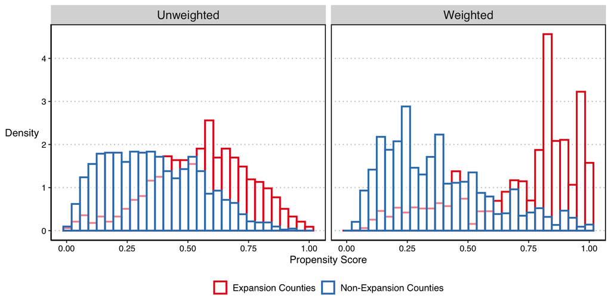

```r
# Finally, we make Figure 1 which reports the distribution of the propensity scores between
# expansion and non-expansion counties.
# first add in propensity scores to the data
plot_data <- bind_rows(
  short_data %>%
    filter(year == 2013) %>%
    mutate(propensity = predict(mod2, ., type = "response"),
           mod = "Unweighted",
           wt = 1),
  short_data %>%
    filter(year == 2013) %>%
    mutate(propensity = predict(mod4, ., type = "response"),
           mod = "Weighted",
           wt = set_wt)
  )

# plot the propensity score distributions by group
plot_data %>%
  mutate(expand = if_else(Treat == 1, "Expansion Counties", "Non-Expansion Counties")) %>%
  ggplot(aes(x = propensity, y = after_stat(density), group = expand, color = expand, weight = wt)) +
  geom_histogram(fill = "white", position = "identity", linewidth = 1, alpha = 0.5) +
  facet_wrap(~mod) +
  scale_color_brewer(palette = 'Set1') +
  labs(x = "Propensity Score", y = "Density") +
  theme(legend.position = 'bottom',
        axis.title.y = element_text(hjust = 0.5, vjust = 0.5, angle = 360),
        strip.text = element_text(size = 14),
        panel.border = element_rect(color = "black", fill = NA, linewidth = 1),
        legend.title = element_blank(),
        axis.title = element_text(size = 12),
        axis.text = element_text(size = 10))
```

**Stata**

```stata
*************************************************
** Figure 1: Distribution of Propensity Scores
*************************************************
    *read data in again and restrict to 2013/2014
    use "did_jel_aca_replication_data", clear
    keep if inlist(year, 2013, 2014) & inlist(yaca,2014,2020,2021,2023,.)
    gen Treat = (yaca==2014)        // 1 = ACA in 2014
    gen Post = (year == 2014)       // 1 = post-expansion year

    *local with covariate names
    local covs perc_female perc_white perc_hispanic ///
           unemp_rate_pc poverty_rate median_income_k

    * Keep only relevant variables
    keep county_code year Treat set_wt crude_rate_20_64 `covs'

    * Reshape everything (outcome + covariates) at once
    reshape wide crude_rate_20_64 `covs', i(county_code) j(year)

    * Generate change in covariates
    foreach v of local covs {
        gen d_`v' = `v'2014 - `v'2013
    }

    * Generate outcome: change in crude mortality
    gen long_y = crude_rate_20_642014 - crude_rate_20_642013

    * Drop missing outcome
    drop if missing(long_y)


    *Unweighted p-score distributions
    eststo ps1: logit Treat ///
        perc_female2013 perc_white2013 perc_hispanic2013 ///
        unemp_rate_pc2013 poverty_rate2013 median_income_k2013, ///
        vce(cluster county_code)


    *estimates use ps1
    predict pscore_unw

    * Expansion counties
    summ pscore_unw if inlist(Treat,0,1)
    local min = r(min)
    local max = r(max)
    local w   = (`max' - `min')/30
    local s   = floor(`min'/`w')*`w'   // align start to a bin edge
    di `w'
    di `s'

    twoway  histogram pscore_unw if Treat == 1 , width(`w') start(`s') fcolor(none) lcolor(red) || ///
            histogram pscore_unw if Treat == 0 , width(`w') start(`s') fcolor(none) lcolor(blue) ///
            ytitle("Density",angle(horizontal)) xtitle("") title("Unweighted") legend(off) ylabel(0(1)4.5) xlabel(,nogrid)

    graph save "pscore_uw.gph", replace


    *Weighted p-score distributions
    eststo ps2: logit Treat ///
        perc_female2013 perc_white2013 perc_hispanic2013 ///
        unemp_rate_pc2013 poverty_rate2013 median_income_k2013, ///
        [iw = set_wt], vce(cluster county_code)


    *estimates use ps2
    predict pscore_w

    * Define group for legend
    gen group = cond(Treat == 1, "Expansion", "Non-Expansion")

    * Expansion counties
    summ pscore_w if inlist(Treat,0,1)
    local min = r(min)
    local max = r(max)
    local w   = (`max' - `min')/30
    local s   = floor(`min'/`w')*`w'   // align start to a bin edge

    twoway  histogram pscore_w if Treat == 1 [fw=set_wt], width(`w') start(`s') fcolor(none) lcolor(red) || ///
            histogram pscore_w if Treat == 0 [fw=set_wt], width(`w') start(`s') fcolor(none) lcolor(blue) ///
            ytitle("") xtitle("Propensity Score") title("Weighted") legend( rows(1)) ylabel(0(1)4.5) xlabel(, nogrid)

    graph save "pscore_w.gph", replace

    *combine graphs and use only one legend and y-axis title
    **NB: differences between the Stata and R histograms are purely down to
    *some arcane disagreement between histogram and ggplot; as can be seen from
    *the actual p-score model estimates, the pscores themselves are identical
    grc1leg2 pscore_uw.gph pscore_w.gph, ///
        title("") xtob1title xtitlefrom("pscore_w.gph") ///
        legendfrom(pscore_w.gph) position(6) ring(2) ///
        cols(2) imargin(4 4 4 4)
    graph display, xsize(10) ysize(5)
```

# 2 $\times$ T DiD setups

In the next section we show how to estimate DiD when you have more than two time periods, what we call the 2 $\times$ T setting.

## Figure 2: County Mortality Trends by Expansion Decision

In **Figure 2** we plot the weighted average county mortality rates over our sample period (2009-2019) for our two groups: those who expand in 2014 and those who have not expanded by 2019.

**R**

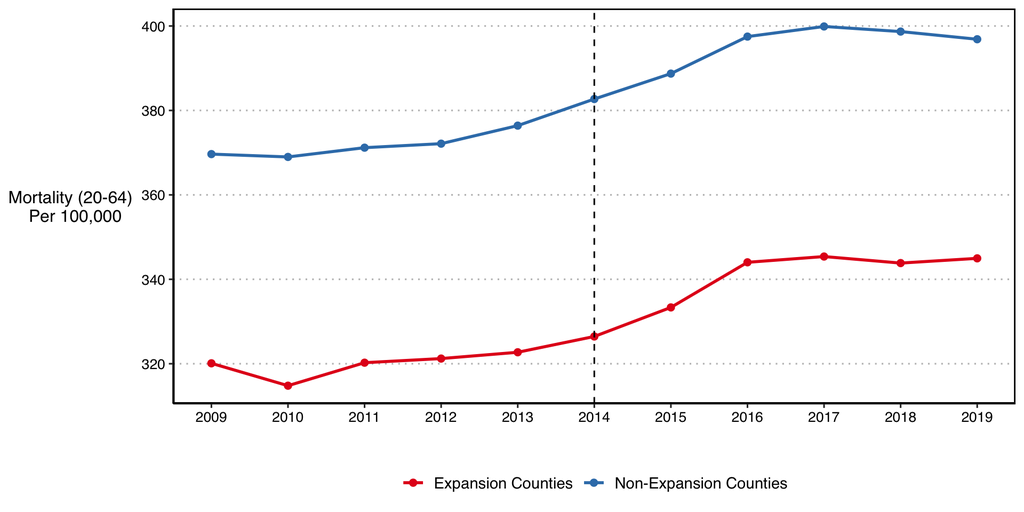

```r
# set seed for reproducibility
set.seed(20240924)

# load cleaned data
mydata <- read_csv(here::here("data", "county_mortality_data.csv")) %>%
  # make state the abbreviation
  mutate(state = str_sub(county, nchar(county) - 1, nchar(county))) %>%
  # drop DC and pre-2014 adoption states
  filter(!(state %in% c("DC", "DE", "MA", "NY", "VT"))) %>%
  # drop states that adopt between 2014 and 2019
  filter(yaca == 2014 | is.na(yaca) | yaca > 2019)

# set the covariates that we're going to use.
covs <- c("perc_female","perc_white", "perc_hispanic",
          "unemp_rate", "poverty_rate", "median_income")

## Clean data and add in covariates
mydata <- mydata %>%
  # make variables
  mutate(perc_white = population_20_64_white / population_20_64 * 100,
         perc_hispanic = population_20_64_hispanic / population_20_64 * 100,
         perc_female = population_20_64_female/ population_20_64 * 100,
         unemp_rate = unemp_rate * 100,
         median_income = median_income / 1000) %>%
  # keep just subset of variables that we will use later
  select(state, county, county_code, year, population_20_64, yaca,
         starts_with("perc_"), crude_rate_20_64, all_of(covs))

# keep only counties with full observations for outcome and covariates in 2013 and 2014
mydata <- mydata %>%
  # allow the aca expansion variable to be missing
  drop_na(!yaca) %>%
  group_by(county_code) %>%
  # need full covariates for 2013 and 2014
  filter(length(which(year == 2013 | year == 2014)) == 2) %>%
  ungroup()

# finally, keep only counties with full mortality data for 2009 to 2019
mydata <- mydata %>%
  group_by(county_code) %>%
  drop_na(crude_rate_20_64) %>%
  filter(n() == 11)

# make ACA and post variables, as well as the weighting variable which is the relevant county
# population in 2013
mydata <- mydata %>%
  mutate(Treat = if_else(yaca == 2014 & !is.na(yaca), 1, 0),
         Post = if_else(year >= 2014, 1, 0)) %>%
  group_by(county_code) %>%
  # make a variable with population weight in 2013
  mutate(set_wt = population_20_64[which(year == 2013)]) %>%
  ungroup()

# make time series plot
mydata %>%
  mutate(expand = if_else(Treat == 1, "Expansion Counties", "Non-Expansion Counties")) %>%
  # get the weighted averages by expansion type and year
  group_by(expand, year) %>%
  summarize(mortality = weighted.mean(crude_rate_20_64, set_wt)) %>%
  # plot
  ggplot(aes(x = year, y = mortality, group = expand, color = expand)) +
  geom_point(size = 2) + geom_line(linewidth = 1) +
  geom_vline(xintercept = 2014, linetype = "dashed") +
  scale_color_brewer(palette = 'Set1') +
  scale_x_continuous(breaks = 2009:2019) +
  labs(x = "", y = "Mortality (20-64) \n Per 100,000") +
  theme(legend.position = 'bottom',
        axis.title.y = element_text(hjust = 0.5, vjust = 0.5, angle = 360),
        strip.text = element_text(size = 14),
        panel.border = element_rect(color = "black", fill = NA, linewidth = 1),
        legend.title = element_blank(),
        axis.title = element_text(size = 12),
        axis.text = element_text(size = 10))
```

**Stata**

```stata
***************************************************************
*1. Figure 2: 2014 versus non-expansion mortality trends
***************************************************************
    *read data in again and restrict to 2013/2014
    use "did_jel_aca_replication_data", clear
    keep if inlist(yaca,2014,2020,2021,2023,.)
    gen Treat = (yaca==2014)        // 1 = ACA in 2014

    *Collapse to means by group × year
    gen expand = cond(Treat==1, "Expansion Counties", "Non-Expansion Counties")

    collapse (mean) crude_rate_20_64 [iw=set_wt], by(expand year)
    rename crude_rate_20_64 mortality

    * Create the plot
    twoway ///
      (line mortality year if expand == "Expansion Counties",      lcolor(red)  lpattern(solid) lwidth(medium)) ///
      (line mortality year if expand == "Non-Expansion Counties",  lcolor(blue) lpattern(solid)  lwidth(medium)) ///
      (scatter mortality year if expand == "Expansion Counties",   msymbol(O)   mcolor(red)) ///
      (scatter mortality year if expand == "Non-Expansion Counties", msymbol(Oh) mcolor(blue))  , ///
      legend(order(1 "Expansion Counties" 2 "Non-Expansion Counties") ///
             pos(6) ring(2) cols(2)) ///
      xtitle("") ///
      ytitle("Mortality (20–64)" "Per 100,000", orientation(horizontal)) ///
      ysize(5) xsize(10) ///
      xline(2013) ///
      xlabel(2009(1)2019, nogrid) ///
      graphregion(color(white)) ///
      plotregion(style(none))
```

## Figure 3: 2 $\times$ T Event Study

In **Figure 3** we report the $2 \times T$ event study without covariates.

**R**

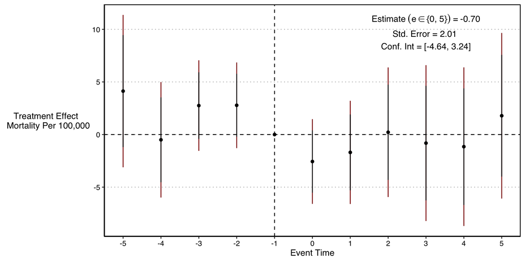

```r
# Make event study plots
# first add in the variables needed to run the CS model - timing group variable (treat_year)
# and county code needs to be numeric
mydata <- mydata %>%
  mutate(treat_year = if_else(yaca == 2014 & !is.na(yaca), 2014, 0),
         county_code = as.numeric(county_code),
         time_to_treat = if_else(Treat == 1, year - treat_year, 0))

# estimate CS models

# get the individual ATT(g,t) estimates
mod <- did::att_gt(
  yname = "crude_rate_20_64",
  tname = "year",
  idname = "county_code",
  gname = "treat_year",
  xformla =  NULL,
  data = mydata,
  panel = TRUE,
  control_group = "nevertreated",
  bstrap = TRUE,
  cband = TRUE,
  est_method = "reg",
  weightsname = "set_wt",
  # faster_mode = TRUE,
  base_period = "universal",
  biters = 25000
)

# confirm you get the same with OLS (standard errors differ because of bootstrap only)
cs_out <- mod

ols_out <- feols(crude_rate_20_64 ~ i(time_to_treat, Treat, ref = -1) | county_code + year,
      data = mydata,
      cluster = ~county_code,
      weights = ~set_wt)

# get the Rambachan/Roth confidence interval
# first save our aggregate event study estimates
es <- did::aggte(
  mod,
  type = "dynamic",
  min_e = -5,
  max_e = 0,
  bstrap = TRUE,
  biters = 25000
)

# source the honest_did code made to fit our estimates
source(here::here('scripts/R/5_honestdid.R'))

# get robust CI
robust_ci <- honest_did(es = es, type = "relative_magnitude")$robust_ci

# get the aggregate value for e = 0:5
agg <- mod %>%
  aggte(type = "dynamic", min_e = 0, max_e = 5,
        bstrap = TRUE, biters = 25000)

# make labels for the estimate, std error, and confidence intervals
label1 <-  paste0("Estimate~(e %in% '{0, 5}')~'='~'", scales::number(agg$overall.att, accuracy = 0.01), "'")

label2 <- paste0("Std. Error = ", scales::number(agg$overall.se, 0.01), " \n",
                 "Conf. Int = [", scales::number(agg$overall.att - 1.96*agg$overall.se, 0.01), ", ",
                 scales::number(agg$overall.att + 1.96*agg$overall.se, 0.01), "]")

# make event study plot for Figure 3
mod %>%
  # Aggregate in event time ("dynamic")
  aggte(type = "dynamic", biters = 25000) %>%
  # get the two confidence intervals
  broom::tidy(conf.int = TRUE) %>%
  # plot
  ggplot(aes(x = event.time, y = estimate)) +
  geom_linerange(aes(ymin = conf.low, ymax = conf.high), color = "darkred") +
  geom_linerange(aes(ymin = point.conf.low, ymax = point.conf.high)) +
  geom_point() +
  geom_vline(xintercept = -1, linetype = "dashed") +
  geom_hline(yintercept = 0, linetype = "dashed") +
  scale_x_continuous(breaks = -5:5) +
  annotate("text", x = 3, y = 11, label = label1, parse = TRUE) +
  annotate("text", x = 3, y = 9, label = label2) +
  labs(x = "Event Time", y = "Treatment Effect \n Mortality Per 100,000") +
  theme(axis.title.y = element_text(hjust = 0.5, vjust = 0.5, angle = 360),
        strip.text = element_text(size = 14),
        panel.border = element_rect(color = "black", fill = NA, linewidth = 1),
        legend.title = element_blank(),
        axis.title = element_text(size = 12),
        axis.text = element_text(size = 10))
```

**Stata**

```stata
***************************************************************
*2. Figure 3: 2xT event-study with no covariates
***************************************************************
    *read data in again and restrict to 2013/2014
    use "did_jel_aca_replication_data", clear
    keep if inlist(yaca,2014,2020,2021,2023,.)

    *Use csdid for simple ES estimation (uniform and non-uniform CIs); use long2!!
    csdid crude_rate_20_64 [iw=set_wt], ///
        ivar(county_code) time(year) gvar(treat_year) ///
        long2 ///
        wboot(reps(25000) rseed(20240924) wbtype(rademacher)) ///
        agg(event)

    *you do actually have to grab the uniform CIs from the posted output
    preserve
        clear
        matrix T  = r(table)
        local cn : colnames T
        matrix llu = T[5,1..colsof(T)]
        matrix ulu = T[6,1..colsof(T)]
        matrix uci = (llu', ulu')
        matrix colnames uci = uci_lower uci_upper
        svmat uci, names(col)
        gen var = ""
        local i = 0
        foreach r of local cn{
            local ++i
            replace var = "`r'" in `i'
        }
        save "testo", replace
    restore

    *save the posted output to a dataset and merge back on the uniform CIs
    regsave, ci
    merge 1:1 var using "testo"
    keep if _merge==3
    drop _merge

    *get average post coefficient, standard error, and CI
    qui sum coef if var=="Post_avg"
    local postcoef : display %03.2f r(mean)
    qui sum stderr if var=="Post_avg"
    local postse : display %03.2f r(mean)
    local postlci : display %03.2f `postcoef'-1.96*`postse'
    local postuci : display %03.2f `postcoef'+1.96*`postse'

    *now only keep the event-study estimates
    keep if substr(var,1,1)=="T"
    keep coef ci* uci* var

    *extract timing components from event aggregation notation in csdid
    gen pre = substr(var,2,1)=="m"
    gen post = substr(var,2,1)=="p"
    gen e = real(substr(var,3,.))
    replace e = -e if pre

    *add omitted period
    local obs = _N+1
    set obs `obs'
    replace coef = 0 in `obs'
    replace e = -1 in `obs'


    *plot the ATT(g,t) for g=2014
    twoway ///
        (rcap uci_lower uci_upper e, ///
        lcolor(red*1.2) msize(0)) ///
        (rcap ci_lower ci_upper e, ///
        lcolor(black) msize(0)) ///
        (scatter coef e, ///
        msym(O) mcolor(black)   ///
        ), ///
        legend(off) ///
        xlabel(-5(1)5, nogrid) ///
        ylabel(-5(5)10) ///
        yline(0, lpattern(dash)) ///
        xline(-1, lpattern(dash)) ///
        xtitle("Event-Time") ///
        ytitle("Treatment Effect" "Mortality Per 100,000", orientation(horizontal) size(small)) ///
        text(10.5 3 "Estimate e ∈ {0,5}=`postcoef'", size(small)) ///
        text(9 3 "Std. Error = `postse'" "Conf. Int = [`postlci',`postuci']", size(small))  ///
        xsize(10) ysize(5)
```

## Rambachan & Roth (2023) Sensitivity Analysis

In the text surrounding the $2 \times T$ event study, we also discuss how you can use the analysis developed in Rambachan and Roth (2023) to test the sensitivity of the ATT estimates to violations of the parallel trends assumption. In particular, we focus on their “relative magnitude” analysis, wherein we assume that any parallel trends violations in the post-period are no larger than the largest violation in the pre-period. In the code below we show how to estimate the credible interval under this bounding approach for $ATT(2014)$ - or the treatment effect in the first year of treatment for those counties that adopted Medicaid expansion.

**R**

```r
# get robust CI
robust_ci %>%
  # keep just relative magnitude = 1
  filter(Mbar == 1) %>%
  # drop extraneous variables
  select(lb, ub, Mbar) %>%
  # round
  mutate_at(c("lb", "ub"), scales::number, accuracy = 0.01) %>%
  # make table
  kable(col.names = c("lower_bound", "upper_bound", "relative_magnitude"),
       align = 'c', booktabs = T) %>%
  kable_styling()
```

| lower_bound | upper_bound | relative_magnitude |
| --- | --- | --- |
| -11.13 | 5.11 | 1 |

**Stata**

```stata
************************************************
*1. read data in again and restrict to 2013/2014
************************************************
    use "did_jel_aca_replication_data", clear
    keep if inlist(yaca,2014,2020,2021,2023,.)

************************************************
*Estimate unconditional csdid version 1.81 (Oct 2025)
************************************************
    csdid crude_rate_20_64 [iw=set_wt], ///
        ivar(county_code) time(year) gvar(treat_year) ///
        long2 ///
        never ///
        wboot(reps(25000) rseed(20240924) wbtype(rademacher)) ///
        agg(event)

    estat event, window(-5,0) post

************************************************
*Honest DiD, relative magnitude only using M=1 for e=0
************************************************
honestdid, type(relative_magnitude) pre(3/6) post(7) mvec(1)

exit
```

## Figure 4: $2 \times T$ Event Study With Covariates

In **Figure 4** we show the $2 \times T$ event studies with covariates using the Callaway and Sant’Anna (2021) estimators - i.e. using outcome regression, IPW, and doubly-robust estimators.

**R**

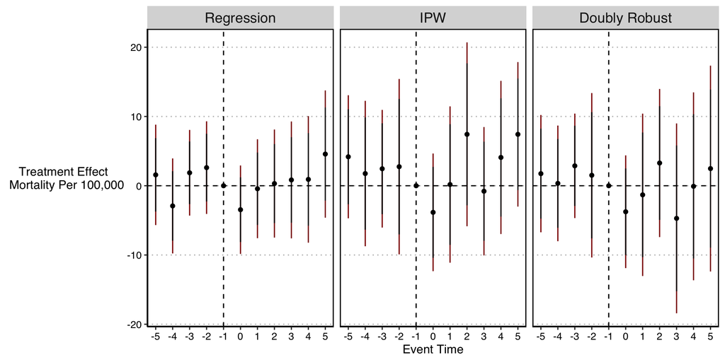

```r
# Estimate the CS Model 3 ways with the three estimation types
# make a function to run CS, varying the estimation type
run_cs <- function(method) {

  # get the ATT(g, t) estimates
  att_gt(
    yname = "crude_rate_20_64",
    tname = "year",
    idname = "county_code",
    gname = "treat_year",
    xformla =  as.formula(paste("~", paste(covs, collapse = "+"))),
    data = mydata,
    panel = TRUE,
    control_group = "nevertreated",
    bstrap = TRUE,
    cband = TRUE,
    est_method = method,
    weightsname = "set_wt",
    # faster_mode = TRUE,
    base_period = "universal",
    biters = 25000
  ) %>%
    # aggregate to event time (dynamic)
    aggte(type = "dynamic", na.rm = TRUE, biters = 25000) %>%
    broom::tidy(conf.int = TRUE) %>%
    mutate(type = method)
}

# estimate it for 3 methods
out <- map_dfr(c("reg", "ipw", "dr"), run_cs)

# make plot for Figure 4 - 2XT Event Study with Covariates
out %>%
  # refactor labels for plot
  mutate(type = case_match(type,
                           "reg" ~ "Regression",
                           "ipw" ~ "IPW",
                           "dr" ~ "Doubly Robust")) %>%
  mutate(type = factor(type, levels = c("Regression", "IPW", "Doubly Robust"))) %>%
  # plot the esti mates and confidence intervals
  ggplot(aes(x = event.time, y = estimate)) +
  geom_linerange(aes(ymin = conf.low, ymax = conf.high), color = "darkred") +
  geom_linerange(aes(ymin = point.conf.low, ymax = point.conf.high)) +
  geom_point() +
  geom_vline(xintercept = -1, linetype = "dashed") +
  geom_hline(yintercept = 0, linetype = "dashed") +
  facet_wrap(~type) +
  scale_x_continuous(breaks = -5:5) +
  labs(x = "Event Time", y = "Treatment Effect \n Mortality Per 100,000") +
  theme(axis.title.y = element_text(hjust = 0.5, vjust = 0.5, angle = 360),
        strip.text = element_text(size = 14),
        panel.border = element_rect(color = "black", fill = NA, linewidth = 1),
        legend.title = element_blank(),
        axis.title = element_text(size = 12),
        axis.text = element_text(size = 10))
```

**Stata**

```stata
***************************************************************
*3. Figure 4: 2xT event-study with covariates
***************************************************************
    *read data in again and restrict to 2013/2014
    use "did_jel_aca_replication_data", clear
    keep if inlist(yaca,2014,2020,2021,2023,.)

    *local with covariate names
    local covs perc_female perc_white perc_hispanic ///
           unemp_rate_pc poverty_rate median_income_k

    *Estimate RA, IPW, and DR using csdid version 1.81 (Oct 2025)
    local reg_title "Regression"
    local stdipw_title "IPW"
    local dripw_title "Doubly Robust"
    foreach m in reg stdipw dripw{
        csdid crude_rate_20_64 `covs' [iw=set_wt], ///
            ivar(county_code) time(year) gvar(treat_year) ///
            method(`m') ///
            long2 ///
            never ///
            wboot(reps(25000) rseed(20240924) wbtype(rademacher)) ///
            pscoretrim(0.995) agg(event)

        *you do actually have to grab the uniform CIs from the posted output
        preserve
            clear
            matrix T  = r(table)
            local cn : colnames T
            matrix llu = T[5,1..colsof(T)]
            matrix ulu = T[6,1..colsof(T)]
            matrix uci = (llu', ulu')
            matrix colnames uci = uci_lower uci_upper
            svmat uci, names(col)
            gen var = ""
            local i = 0
            foreach r of local cn{
                local ++i
                replace var = "`r'" in `i'
            }
            save "testo", replace
        restore

        *save the posted output to a dataset and merge back on the uniform CIs
        preserve
            regsave, ci
            merge 1:1 var using "testo"
            keep if _merge==3
            drop _merge

            *get average post coefficient, standard error, and CI
            qui sum coef if var=="Post_avg"
            local postcoef : display %03.2f r(mean)
            qui sum stderr if var=="Post_avg"
            local postse : display %03.2f r(mean)
            local postlci : display %03.2f `postcoef'-1.96*`postse'
            local postuci : display %03.2f `postcoef'+1.96*`postse'

            *now only keep the event-study estimates
            keep if substr(var,1,1)=="T"
            keep coef ci* uci* var

            *extract timing components from event aggregation notation in csdid
            gen pre = substr(var,2,1)=="m"
            gen post = substr(var,2,1)=="p"
            gen e = real(substr(var,3,.))
            replace e = -e if pre

            *add omitted period
            local obs = _N+1
            set obs `obs'
            replace coef = 0 in `obs'
            replace e = -1 in `obs'


            *plot the ATT(g,t) for g=2014
            twoway ///
                (rcap uci_lower uci_upper e, ///
                lcolor(red*1.2) msize(0)) ///
                (rcap ci_lower ci_upper e, ///
                lcolor(black) msize(0)) ///
                (scatter coef e, ///
                msym(O) mcolor(black)   ///
                ), ///
                legend(off) ///
                xlabel(-5(1)5, nogrid) ///
                ylabel(-20(10)20) ///
                xline(-1, lpattern(dash)) ///
                yline(0, lpattern(dash)) ///
                xtitle("Event-Time") ///
                ytitle("") ///
                title("``m'_title'") ///
                xsize(10) ysize(5)

                graph save "`m'.gph", replace
        restore
    }

    *combine graphs and use only one legend and y-axis title
    **NB: differences between the Stata and R come from the bootstrap uncertainty
    **analytic standard errors are identical
    grc1leg2 reg.gph stdipw.gph dripw.gph, ///
        title("") xtob1title xtitlefrom("reg.gph") ///
        l1title("Treatment Effect" "Mortality Per 100,000", size(small) orientation(horizontal)) ///
        loff ///
        ycommon ///
        position(6) ring(2) ///
        cols(3) imargin(4 4 4 4)

    graph display, xsize(12) ysize(5)




exit
```

# G $\times$ T DiD setups

We end the paper with the staggered adoption setting, with $G$ treatment groups and $T > 2$ time periods.

## Figure 5: Mortality Trends by Expansion Decision with Staggered Timing

In **Figure 5** we plot the trends in weighted-average county mortality rates by treatment timing groups from 2009 to 2019.

**R**

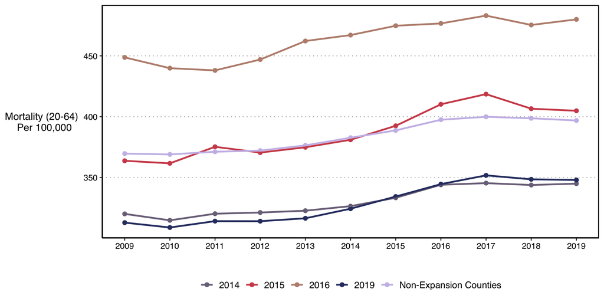

```r
# set seed for reproducibility
set.seed(20240924)

# load cleaned data
mydata <- read_csv(here::here("data", "county_mortality_data.csv")) %>%
  # make state the abbreviation
  mutate(state = str_sub(county, nchar(county) - 1, nchar(county))) %>%
  # drop DC and pre-2014 adoption states
  filter(!(state %in% c("DC", "DE", "MA", "NY", "VT")))

# set the covariates that we're going to use.
covs <- c("perc_female","perc_white", "perc_hispanic", "unemp_rate", "poverty_rate", "median_income")

## Clean data and add in covariates
mydata <- mydata %>%
  # make variables
  mutate(perc_white = population_20_64_white / population_20_64 * 100,
         perc_hispanic = population_20_64_hispanic / population_20_64 * 100,
         perc_female = population_20_64_female/ population_20_64 * 100,
         unemp_rate = unemp_rate * 100,
         median_income = median_income / 1000) %>%
  # keep just subset of variables that we will use later
  select(state, county, county_code, year, population_20_64, yaca,
         starts_with("perc_"), crude_rate_20_64, all_of(covs))

# keep only counties with full observations for outcome and covariates in 2013 and 2014
mydata <- mydata %>%
  # allow the aca expansion variable to be missing
  drop_na(!yaca) %>%
  group_by(county_code) %>%
  # need full covariates for 2013 and 2014
  filter(length(which(year == 2013 | year == 2014)) == 2) %>%
  ungroup()

# finally, keep only counties with full mortality data for 2009 to 2019
mydata <- mydata %>%
  group_by(county_code) %>%
  drop_na(crude_rate_20_64) %>%
  filter(n() == 11)

# make smaller dataset
mydata <- mydata %>%
  mutate(Treat = if_else(!is.na(yaca) & yaca <= 2019, 1, 0),
         treat_year = if_else(!is.na(yaca) & yaca <= 2019, yaca, 0),
         Post = if_else(year >= 2014, 1, 0)) %>%
  group_by(county_code) %>%
  # make a variable with population weight in 2013
  mutate(set_wt = population_20_64[which(year == 2013)]) %>%
  ungroup()

# make time series plot by timing group (Figure 5)
mydata %>%
  # identify the groups
  mutate(treat_year = if_else(treat_year == 0, "Non-Expansion Counties", as.character(treat_year))) %>%
  # get weighted average mortality by gtiming-group and year
  group_by(treat_year, year) %>%
  summarize(mortality = weighted.mean(crude_rate_20_64, set_wt)) %>%
  ggplot(aes(x = year, y = mortality, group = as.factor(treat_year), color = as.factor(treat_year))) +
  geom_point(size = 2) + geom_line(linewidth = 1) +
  scale_color_manual(values = c("#7C7189", "#D04E59", "#BC8E7D", "#2F3D70", "#CABEE9")) +
  scale_x_continuous(breaks = 2009:2019) +
  labs(x = "", y = "Mortality (20-64) \n Per 100,000") +
  theme(legend.position = 'bottom',
        axis.title.y = element_text(hjust = 0.5, vjust = 0.5, angle = 360),
        strip.text = element_text(size = 14),
        panel.border = element_rect(color = "black", fill = NA, linewidth = 1),
        legend.title = element_blank(),
        axis.title = element_text(size = 12),
        axis.text = element_text(size = 10))
```

**Stata**

```stata
**************************************************************************
*1. Figure 5: Mortality Trends by Timing Group
**************************************************************************
    *read data in again and relabel treatment groups, specifically the "non-expansion" group
    use "did_jel_aca_replication_data", clear

    *Define treatment timing labels
    replace treat_str = "Non-Expansion Counties" if inlist(treat_str, "0", "2020", "2021", "2022", "2023")

    collapse (mean) crude_rate [aw = set_wt], by(treat_str year)

    * Plot trends by Timing Group
    twoway ///
        (connected crude_rate year if treat_str == "Non-Expansion Counties", ///
            lcolor(purple*0.35) lwidth(medthick) mcolor(purple*0.35) msymbol(O)) ///
        (connected crude_rate year if treat_str == "2014", ///
            lcolor(gray*1.2) lwidth(medthick) mcolor(gray*1.2) msymbol(O)) ///
        (connected crude_rate year if treat_str == "2015", ///
            lcolor(red) lwidth(medthick) mcolor(red*1.5) msymbol(O)) ///
        (connected crude_rate year if treat_str == "2016", ///
            lcolor(brown) lwidth(medthick) mcolor(brown) msymbol(O)) ///
        (connected crude_rate year if treat_str == "2019", ///
            lcolor(navy) lwidth(medthick) mcolor(navy) msymbol(O)), ///
        ///
        legend(order(2 "2014" 3 "2015" 4 "2016" 5 "2019" 1 "Non-Expansion Counties") ///
                pos(6) ring(2) rows(1) region(lcolor(none)) size(small)) ///
        ytitle("Mortality (20–64)" "per 100,000", size(small) orientation(horizontal)) ///
        ylabel(350 400 450, angle(0) labsize(small) nogrid) ///
        xtitle("") xlabel(2009(1)2019, labsize(small)) ///
        graphregion(color(white)) ///
        name(fig5, replace)

        graph display, xsize(10) ysize(5)
```

## Figure 6: ATT(g, t)s for Each Expansion Group

With the estimator from Callaway & Sant’Anna (2021) we can estimate the group-time average treatment effects - what we call ATT(g, t) - for each group and time period. We plot these cohort-specific treatment effects in **Figure 6**.

**R**

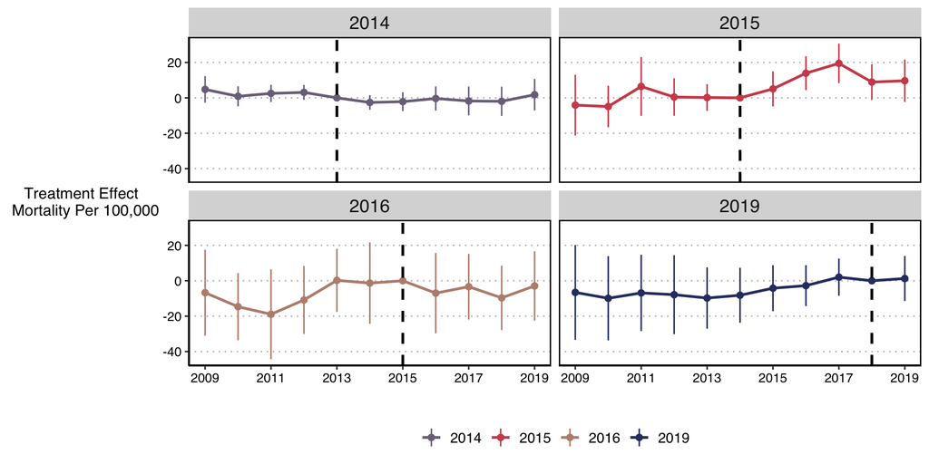

```r
# reclassify the county code as numeric for Callaway/Sant'Anna
mydata <- mydata %>%
  mutate(county_code = as.numeric(county_code))

# get the ATT(g,t)'s
mod_no_x <- att_gt(
  yname = "crude_rate_20_64",
  tname = "year",
  idname = "county_code",
  gname = "treat_year",
  xformla =  NULL,
  data = mydata,
  panel = TRUE,
  control_group = "notyettreated",
  bstrap = TRUE,
  biters = 25000,
  cband = TRUE,
  weightsname = "set_wt",
  # faster_mode = TRUE,
  base_period = "universal"
)

# make plots in calendar time by timing group
mod_no_x %>%
  # get the estimates and confidence intervals
  broom::tidy(conf.int = TRUE) %>%
  mutate(group = as.character(group)) %>%
  # plot the estimates and CIs
  ggplot(aes(x = time, y = estimate, color = group)) +
  geom_point(size = 2) + geom_line(linewidth = 1) +
  geom_linerange(aes(ymin = conf.low, ymax = conf.high)) +
  scale_x_continuous(breaks = seq(2009, 2019, by = 2),
                     labels = seq(2009, 2019, by = 2)) +
  scale_color_manual(values = c("#7C7189", "#D04E59", "#BC8E7D", "#2F3D70")) +
  geom_vline(aes(xintercept = as.numeric(group) - 1), linetype = "dashed", linewidth = 1) +
  labs(x = "", y = "Treatment Effect \n Mortality Per 100,000") +
  facet_wrap(~group) +
  theme(legend.position = 'bottom',
        axis.title.y = element_text(hjust = 0.5, vjust = 0.5, angle = 360),
        strip.text = element_text(size = 14),
        panel.border = element_rect(color = "black", fill = NA, linewidth = 1),
        legend.title = element_blank(),
        axis.title = element_text(size = 12),
        axis.text = element_text(size = 10))
```

**Stata**

```stata
**************************************************************************
*2.   Figure 6: ATT(g,t) by Calendar Time
**************************************************************************
    *read data in
    use "did_jel_aca_replication_data", clear

    *Estimate group × time effects
    csdid crude_rate [iw=set_wt], ///
        ivar(county_code) ///
        time(year) ///
        gvar(treat_year) ///
        long2 ///
        notyet ///
        wboot(reps(25000) rseed(20240924) wbtype(rademacher))

    *adding the omitted category to every g is very annoying ni the matrix style, so do the graphs using regsave
    regsave

    *extract timing components from csdid
    gen g = real(substr(var,2,4))
    gen t1 = real(substr(var,9,4))
    gen t2 = real(substr(var,14,4))
    gen t = (t1)*(t2==g-1) + (t2)*(t1==g-1)

    *add omitted period
    preserve
        keep g
        duplicates drop
        gen t = g-1
        gen coef = 0
        save testo, replace
    restore
    append using testo

    *make CIs
    gen lci = coef - 1.96*stderr
    gen uci = coef + 1.96*stderr
    keep coef lci uci g t
    sort g t

    *plot the ATT(g,t) for g=2014
    twoway ///
        (rcap lci uci t if g==2014, ///
        lcolor(gray*1.2) msize(0)) ///
        (scatter coef t if g==2014, ///
        msym(O) mcolor(gray*1.2)    ///
        c(l) lcolor(gray*1.2)       ///
        ), ///
        legend(off) ///
        xlabel(2009(2)2019, nogrid) ///
        ylabel(-40(20)20) ///
        xline(2013, lpattern(dash)) ///
        title("2014") ///
        xtitle("") ///
        ytitle("", orientation(horizontal)) ///
        xsize(10) ysize(5)

        graph save g2014.gph, replace

    *plot the ATT(g,t) for g=2015
    twoway ///
        (rcap lci uci t if g==2015, ///
        lcolor(red*1.5) msize(0)) ///
        (scatter coef t if g==2015, ///
        msym(O) mcolor(red*1.5)     ///
        c(l) lcolor(red*1.5)        ///
        ), ///
        legend(off) ///
        xlabel(2009(2)2019, nogrid) ///
        ylabel(-40(20)20) ///
        xline(2014, lpattern(dash)) ///
        title("2015") ///
        xtitle("") ///
        ytitle("", orientation(horizontal)) ///
        xsize(10) ysize(5)

        graph save g2015.gph, replace

    *plot the ATT(g,t) for g=2016
    twoway ///
        (rcap lci uci t if g==2016, ///
        lcolor(brown) msize(0)) ///
        (scatter coef t if g==2016, ///
        msym(O) mcolor(brown)   ///
        c(l) lcolor(brown)      ///
        ), ///
        legend(off) ///
        xlabel(2009(2)2019, nogrid) ///
        ylabel(-40(20)20) ///
        xline(2015, lpattern(dash)) ///
        title("2016") ///
        xtitle("") ///
        ytitle("", orientation(horizontal)) ///
        xsize(10) ysize(5)

        graph save g2016.gph, replace

    *plot the ATT(g,t) for g=2019
    twoway ///
        (rcap lci uci t if g==2019, ///
        lcolor(navy) msize(0)) ///
        (scatter coef t if g==2019, ///
        msym(O) mcolor(navy)    ///
        c(l) lcolor(navy)       ///
        ), ///
        legend(off) ///
        xlabel(2009(2)2019, nogrid) ///
        ylabel(-40(20)20) ///
        xline(2018, lpattern(dash)) ///
        title("2019") ///
        xtitle("") ///
        ytitle() ///
        xsize(10) ysize(5)

        graph save g2019.gph, replace

    graph combine g2014.gph g2015.gph g2016.gph g2019.gph, ///
        title("Treatment Effect" "Mortality per 100,000", size(small) orientation(horizontal) pos(9) ring(2))  ///
        cols(2) imargin(4 4 4 4)

    graph display, xsize(10) ysize(5)
```

## Figure 7: ATT(g, t) in Event Time

We show how you can stack these group-time average treatment effects in relative, or event, time in **Figure 7**.

**R**

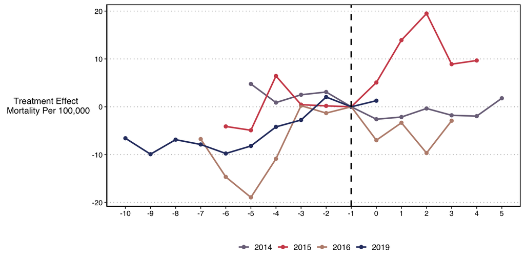

```r
# Make a different plot that reports the ATT(g,t)s in relative time
mod_no_x %>%
  # get the estimates and CIs
  broom::tidy() %>%
  # define relative time for each group
  mutate(rel_time = time - group) %>%
  # plot
  ggplot(aes(x = rel_time, y = estimate, group = as.factor(group), color = as.factor(group))) +
  geom_point(size = 2) + geom_line(linewidth = 1) +
  geom_vline(xintercept = -1, linetype = "dashed", linewidth = 1) +
  scale_color_manual(values = c("#7C7189", "#D04E59", "#BC8E7D", "#2F3D70")) +
  scale_x_continuous(breaks = -10:5) +
  labs(x = "", y = "Treatment Effect \n Mortality Per 100,000") +
  theme(legend.position = 'bottom',
        axis.title.y = element_text(hjust = 0.5, vjust = 0.5, angle = 360),
        strip.text = element_text(size = 14),
        panel.border = element_rect(color = "black", fill = NA, linewidth = 1),
        legend.title = element_blank(),
        axis.title = element_text(size = 12),
        axis.text = element_text(size = 10))
```

**Stata**

```stata
**************************************************************************
*3.   Figure 7: ATT(g,t) in event-time
**************************************************************************
        *read data in
    use "did_jel_aca_replication_data", clear

    *Estimate group × time effects
    csdid crude_rate [iw=set_wt], ///
        ivar(county_code) ///
        time(year) ///
        gvar(treat_year) ///
        long2 ///
        notyet ///
        wboot(reps(25000) rseed(20240924) wbtype(rademacher))

    *adding the omitted category to every g is very annoying ni the matrix style, so do the graphs using regsave
    regsave

    *extract timing components from csdid
    gen g = real(substr(var,2,4))
    gen t1 = real(substr(var,9,4))
    gen t2 = real(substr(var,14,4))
    gen t = (t1)*(t2==g-1) + (t2)*(t1==g-1)

    *add omitted period
    preserve
        keep g
        duplicates drop
        gen t = g-1
        gen coef = 0
        save testo, replace
    restore
    append using testo

    *make CIs
    gen lci = coef - 1.96*stderr
    gen uci = coef + 1.96*stderr
    keep coef lci uci g t
    sort g t

  gen e = t-g
    keep g e coef
    keep if g<.
    reshape wide coef, i(e) j(g)
    twoway ///
        scatter coef2014 coef2015 coef2016 coef2019 e, ///
        msym(o o o o) mcolor(gray*1.2 red*1.5 brown navy) ///
        c(l l l l) lcolor(gray*1.2 red*1.5 brown navy) lwidth(medthick medthick medthick medthick) ///
        legend(order(1 "2014" 2 "2015" 3 "2016" 4 "2019") rows(1) pos(6) ring(2) size(small)) ///
        xlabel(-10(1)5, nogrid) ///
        ylabel(-20(10)20) ///
        xline(-1, lpattern(dash)) ///
        title("") ///
        xtitle("") ///
        ytitle() ///
        xsize(10) ysize(5)
```

## Figure 8: G $\times$ T Event Study Without Covariates

Finally, we demonstrate how to estimate DiD in the $G \times T$ setting by leverage treatment timing and not-yet-treated groups for identification using the doubly-robust method from Callaway and Sant’Anna (2021). First, in **Figure 8** we show the DiD event study estimates without covariates.

**R**

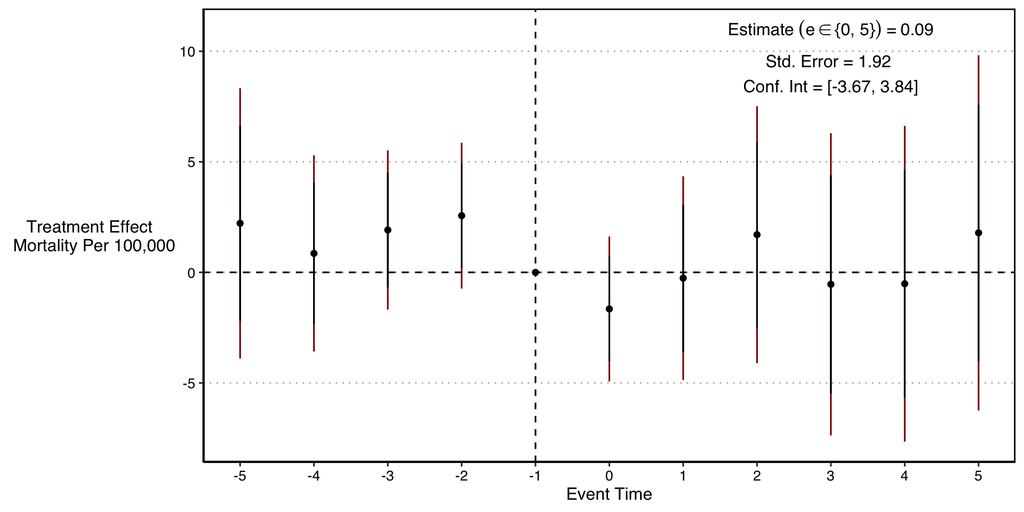

```r
# Make a full -5 to + 5 event study plot for no covariates
# using Callaway/Sant'Anna with not-yet-treated

# get the aggregate value for e = 0:5
agg <- mod_no_x %>%
  aggte(type = "dynamic", min_e = 0, max_e = 5,
        bstrap = TRUE, biters = 25000)

# make labels for the estimate, std error, and confidence intervals
label1 <-  paste0("Estimate~(e %in% '{0, 5}')~'='~'", scales::number(agg$overall.att, accuracy = 0.01), "'")

label2 <- paste0("Std. Error = ", scales::number(agg$overall.se, 0.01), " \n",
                 "Conf. Int = [", scales::number(agg$overall.att - 1.96*agg$overall.se, 0.01), ", ",
                 scales::number(agg$overall.att + 1.96*agg$overall.se, 0.01), "]")

# make G*T event study plot without covariates
mod_no_x %>%
  # aggregate into relative time (dynamic)
  aggte(type = "dynamic") %>%
  broom::tidy(conf.int = TRUE) %>%
  # keep just -5 to + 5
  filter(event.time %>% between(-5, 5)) %>%
  # plot
  ggplot(aes(x = event.time, y = estimate)) +
  geom_linerange(aes(ymin = conf.low, ymax = conf.high), color = "darkred") +
  geom_linerange(aes(ymin = point.conf.low, ymax = point.conf.high)) +
  geom_point() +
  geom_vline(xintercept = -1, linetype = "dashed") +
  geom_hline(yintercept = 0, linetype = "dashed") +
  scale_x_continuous(breaks = -5:5) +
  annotate("text", x = 3, y = 11, label = label1, parse = TRUE) +
  annotate("text", x = 3, y = 9, label = label2) +
  labs(x = "Event Time", y = "Treatment Effect \n Mortality Per 100,000") +
  theme(axis.title.y = element_text(hjust = 0.5, vjust = 0.5, angle = 360),
        strip.text = element_text(size = 14),
        panel.border = element_rect(color = "black", fill = NA, linewidth = 1),
        legend.title = element_blank(),
        axis.title = element_text(size = 12),
        axis.text = element_text(size = 10))
```

**Stata**

```stata
/**************************************************************************
4. Figure 8: Event study without covariates
**************************************************************************/
    *read data in
    use "did_jel_aca_replication_data", clear

    *Use csdid for simple ES estimation (uniform and non-uniform CIs); use long2!!
    csdid crude_rate_20_64 [iw=set_wt], ///
        ivar(county_code) time(year) gvar(treat_year) ///
        long2 ///
        notyet ///
        wboot(reps(25000) rseed(20240924) wbtype(rademacher)) ///
        agg(event)

    *you do actually have to grab the uniform CIs from the posted output
    preserve
        clear
        matrix T  = r(table)
        local cn : colnames T
        matrix llu = T[5,1..colsof(T)]
        matrix ulu = T[6,1..colsof(T)]
        matrix uci = (llu', ulu')
        matrix colnames uci = uci_lower uci_upper
        svmat uci, names(col)
        gen var = ""
        local i = 0
        foreach r of local cn{
            local ++i
            replace var = "`r'" in `i'
        }
        save "testo", replace
    restore

    *save the posted output to a dataset and merge back on the uniform CIs
    regsave, ci
    merge 1:1 var using "testo"
    keep if _merge==3
    drop _merge

    *get average post coefficient, standard error, and CI
    qui sum coef if var=="Post_avg"
    local postcoef : display %03.2f r(mean)
    qui sum stderr if var=="Post_avg"
    local postse : display %03.2f r(mean)
    local postlci : display %03.2f `postcoef'-1.96*`postse'
    local postuci : display %03.2f `postcoef'+1.96*`postse'

    *now only keep the event-study estimates
    keep if substr(var,1,1)=="T"
    keep coef ci* uci* var

    *extract timing components from event aggregation notation in csdid
    gen pre = substr(var,2,1)=="m"
    gen post = substr(var,2,1)=="p"
    gen e = real(substr(var,3,.))
    replace e = -e if pre

    *add omitted period
    local obs = _N+1
    set obs `obs'
    replace coef = 0 in `obs'
    replace e = -1 in `obs'

    *plot only -5 to 5
    keep if inrange(e,-5,5)

    *plot the ATT(g,t) for g=2014
    twoway ///
        (rcap uci_lower uci_upper e, ///
        lcolor(red*1.2) msize(0)) ///
        (rcap ci_lower ci_upper e, ///
        lcolor(black) msize(0)) ///
        (scatter coef e, ///
        msym(O) mcolor(black)   ///
        ), ///
        legend(off) ///
        xlabel(-5(1)5, nogrid) ///
        ylabel(-20(10)20) ///
        yline(0, lpattern(dash)) ///
        xline(-1, lpattern(dash)) ///
        xtitle("Event-Time") ///
        ytitle("Treatment Effect" "Mortality Per 100,000", orientation(horizontal) size(small)) ///
        text(18.5 3 "Estimate e ∈ {0,5}=`postcoef'", size(small)) ///
        text(15.5 3 "Std. Error = `postse'" "Conf. Int = [`postlci',`postuci']", size(small))   ///
        xsize(10) ysize(5)
```

## Figure 9: G $\times$ T Event Study With Covariates

**Figure 9** presents the event study results adjusting for the covariates using the doubly-robust method.

**R**

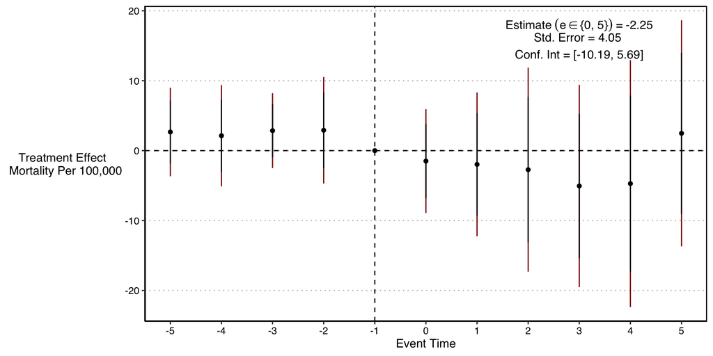

```r
# Now re-estimate and plot the same GXT estimates with covariates
# set.seed(20240924)
mod_with_x <- att_gt(
  yname = "crude_rate_20_64",
  tname = "year",
  idname = "county_code",
  gname = "treat_year",
  xformla =  as.formula(paste("~", paste(covs, collapse = "+"))),
  data = mydata,
  panel = TRUE,
  control_group = "notyettreated",
  bstrap = TRUE,
  biters = 25000,
  cband = TRUE,
  est_method = "dr",
  weightsname = "set_wt",
  # faster_mode = TRUE,
  base_period = "universal"

)

# get the aggregate value for e = 0:5
agg <- mod_with_x %>%
  aggte(type = "dynamic", min_e = 0, max_e = 5,
        bstrap = TRUE, biters = 25000)

# make labels for the estimate, std error, and confidence intervals
label1 <-  paste0("Estimate~(e %in% '{0, 5}')~'='~'", scales::number(agg$overall.att, accuracy = 0.01), "'")

label2 <- paste0("Std. Error = ", scales::number(agg$overall.se, 0.01), " \n",
                 "Conf. Int = [", scales::number(agg$overall.att - 1.96*agg$overall.se, 0.01), ", ",
                 scales::number(agg$overall.att + 1.96*agg$overall.se, 0.01), "]")

# make event study plot for GXT with covariates
mod_with_x %>%
  # aggregate to event time (dynamic)
  aggte(type = "dynamic") %>%
  broom::tidy(conf.int = TRUE) %>%
  # filter years
  filter(event.time %>% between(-5, 5)) %>%
  # plot
  ggplot(aes(x = event.time, y = estimate)) +
  geom_linerange(aes(ymin = conf.low, ymax = conf.high), color = "darkred") +
  geom_linerange(aes(ymin = point.conf.low, ymax = point.conf.high)) +
  geom_point() +
  geom_vline(xintercept = -1, linetype = "dashed") +
  geom_hline(yintercept = 0, linetype = "dashed") +
  scale_x_continuous(breaks = -5:5) +
  annotate("text", x = 3, y = 18, label = label1, parse = TRUE) +
  annotate("text", x = 3, y = 15, label = label2) +
  labs(x = "Event Time", y = "Treatment Effect \n Mortality Per 100,000") +
  theme(axis.title.y = element_text(hjust = 0.5, vjust = 0.5, angle = 360),
        strip.text = element_text(size = 14),
        panel.border = element_rect(color = "black", fill = NA, linewidth = 1),
        legend.title = element_blank(),
        axis.title = element_text(size = 12),
        axis.text = element_text(size = 10))
```

**Stata**

```stata
/**************************************************************************
5. Figure 9: Event study with covariates
**************************************************************************/
    *read data in
    use "did_jel_aca_replication_data", clear

    *local with covariate names
    local covs perc_female perc_white perc_hispanic ///
           unemp_rate_pc poverty_rate median_income_k

    *Use csdid for simple ES estimation (uniform and non-uniform CIs); use long2!!
    csdid crude_rate_20_64 `covs' [iw=set_wt], ///
        ivar(county_code) time(year) gvar(treat_year) ///
        method(dripw) ///
        long2 ///
        notyet ///
        pscoretrim(0.995) ///
        wboot(reps(25000) rseed(20240924) wbtype(rademacher))   ///
        agg(event)

    *you do actually have to grab the uniform CIs from the posted output
    preserve
        clear
        matrix T  = r(table)
        local cn : colnames T
        matrix llu = T[5,1..colsof(T)]
        matrix ulu = T[6,1..colsof(T)]
        matrix uci = (llu', ulu')
        matrix colnames uci = uci_lower uci_upper
        svmat uci, names(col)
        gen var = ""
        local i = 0
        foreach r of local cn{
            local ++i
            replace var = "`r'" in `i'
        }
        save "testo", replace
    restore

    *save the posted output to a dataset and merge back on the uniform CIs
    regsave, ci
    merge 1:1 var using "testo"
    keep if _merge==3
    drop _merge

    *get average post coefficient, standard error, and CI
    qui sum coef if var=="Post_avg"
    local postcoef : display %03.2f r(mean)
    qui sum stderr if var=="Post_avg"
    local postse : display %03.2f r(mean)
    local postlci : display %03.2f `postcoef'-1.96*`postse'
    local postuci : display %03.2f `postcoef'+1.96*`postse'

    *now only keep the event-study estimates
    keep if substr(var,1,1)=="T"
    keep coef ci* uci* var

    *extract timing components from event aggregation notation in csdid
    gen pre = substr(var,2,1)=="m"
    gen post = substr(var,2,1)=="p"
    gen e = real(substr(var,3,.))
    replace e = -e if pre

    *add omitted period
    local obs = _N+1
    set obs `obs'
    replace coef = 0 in `obs'
    replace e = -1 in `obs'

    *plot only -5 to 5
    keep if inrange(e,-5,5)

    *plot the ATT(g,t) for g=2014
    twoway ///
        (rcap uci_lower uci_upper e, ///
        lcolor(red*1.2) msize(0)) ///
        (rcap ci_lower ci_upper e, ///
        lcolor(black) msize(0)) ///
        (scatter coef e, ///
        msym(O) mcolor(black)   ///
        ), ///
        legend(off) ///
        xlabel(-5(1)5, nogrid) ///
        ylabel(-20(10)20) ///
        yline(0, lpattern(dash)) ///
        xline(-1, lpattern(dash)) ///
        xtitle("Event-Time") ///
        ytitle("Treatment Effect" "Mortality Per 100,000", orientation(horizontal) size(small)) ///
        text(19.4 3 "Estimate e ∈ {0,5}=`postcoef'", size(small)) ///
        text(15.5 3 "Std. Error = `postse'" "Conf. Int = [`postlci',`postuci']", size(small))   ///
        xsize(10) ysize(5)
```